# Análise Exploratória dos Dados - Dataset Vinhos Portugueses Conceitos Estatísticos para IA

# Avaliação 02 - Conceitos Estatísticos para IA

## Grupo:

- Carlos Eduardo Barbosa - 335518
- Daniel Gregoris Guarino - 335398
- Fabio de Campos Bordin - 336263
- Fernando Bareno Calo - 335434

```r
# diretório de trabalho
getwd()
```

```
## [1] "C:/Users/Daniel Guarino/Documents/fiap/conceitos-estatisticos-para-ia/Trabalho/StartupOne/src/R/BaseWine Quality"
```

```r
dir = 'C:/Users/Daniel Guarino/Documents/fiap/conceitos-estatisticos-para-ia/Trabalho/StartupOne/src/R/BaseWine Quality/DataSource'
setwd(dir)

data_vinhos <- read.csv("Data.csv", sep = ";", stringsAsFactors = FALSE)
```

## 2. Limpeza de dados

```r
# 13 variáveis + id
# 6497 registros
dim(data_vinhos)
```

```
## [1] 6497   14
```

```r
# estrutura do dataset - variáveis string ao invés de numérico
str(data_vinhos)
```

```
## 'data.frame':    6497 obs. of  14 variables:
##  $ id_vinho          : int  1 2 3 4 5 6 7 8 9 10 ...
##  $ fixedacidity      : chr  "6,6" "6,7" "10,6" "5,4" ...
##  $ volatileacidity   : chr  "0,24" "0,34" "0,31" "0,18" ...
##  $ citricacid        : chr  "0,35" "0,43" "0,49" "0,24" ...
##  $ residualsugar     : chr  "7,7" "1,6" "2,2" "4,8" ...
##  $ chlorides         : chr  "0,031" "0,041" "0,063" "0,041" ...
##  $ freesulfurdioxide : chr  "36" "29" "18" "30" ...
##  $ totalsulfurdioxide: chr  "135" "114" "40" "113" ...
##  $ density           : chr  "0,9938" "0,99014" "0,9976" "0,99445" ...
##  $ pH                : chr  "3,19" "3,23" "3,14" "3,42" ...
##  $ sulphates         : chr  "0,37" "0,44" "0,51" "0,4" ...
##  $ alcohol           : chr  "10,5" "12,6" "9,8" "9,4" ...
##  $ quality           : int  5 6 6 6 5 5 4 6 7 6 ...
##  $ Vinho             : chr  "WHITE" "WHITE" "RED" "WHITE" ...
```

```r
# carregar pacote dplyr
library(dplyr)
# mudar o nome das variáveis para português usando a função mutate do pacote dplyR
data_vinhos <- data_vinhos %>% mutate(acidez_fixa = fixedacidity) %>% mutate(acidez_volatil = volatileacidity) %>%
    mutate(acido_citrico = citricacid) %>% mutate(acucar_residual = residualsugar) %>%
    mutate(cloretos = chlorides) %>% mutate(dioxido_de_enxofre_livre = freesulfurdioxide) %>%
    mutate(dioxido_de_enxofre_total = totalsulfurdioxide) %>% mutate(densidade = density) %>%
    mutate(sulfatos = sulphates ) %>% mutate(alcool = alcohol) %>% mutate(qualidade = quality) %>%
    mutate(vinho = Vinho)
```

```r
# com a mudança das variáveis usando mutate o dataset fica com as variáveis originais em inglês mais as novas
# em português.
dim(data_vinhos)
```

```
## [1] 6497   26
```

```r
# Para ficar apenas com as variáveis com nome em português usamos a função select do pacote dplyR armazenando
# em uma nova variavel data_vinhos2. Neste novo dataset não incluimos a variável id.
data_vinhos2 <- data_vinhos %>% select(acidez_fixa, acidez_volatil, acido_citrico, acucar_residual,
                                      cloretos, dioxido_de_enxofre_livre, dioxido_de_enxofre_total,
                                      densidade, pH, sulfatos, alcool, qualidade, vinho)
```

```r
# conferindo: 13 variáveis
dim(data_vinhos2)
```

```
## [1] 6497   13
```

```r
head(data_vinhos2,10)
```

|  | acidez_fixa | acidez_volatil | acido_citrico | acucar_residual | cloretos | dioxido_de_enxofre_livre | dioxido_de_enxofre_total | densidade | pH | sulfatos | alcool | qualidade | vinho |
| --- | --- | --- | --- | --- | --- | --- | --- | --- | --- | --- | --- | --- | --- |
| 1 | 6,6 | 0,24 | 0,35 | 7,7 | 0,031 | 36 | 135 | 0,9938 | 3,19 | 0,37 | 10,5 | 5 | WHITE |
| 2 | 6,7 | 0,34 | 0,43 | 1,6 | 0,041 | 29 | 114 | 0,99014 | 3,23 | 0,44 | 12,6 | 6 | WHITE |
| 3 | 10,6 | 0,31 | 0,49 | 2,2 | 0,063 | 18 | 40 | 0,9976 | 3,14 | 0,51 | 9,8 | 6 | RED |
| 4 | 5,4 | 0,18 | 0,24 | 4,8 | 0,041 | 30 | 113 | 0,99445 | 3,42 | 0,4 | 9,4 | 6 | WHITE |
| 5 | 6,7 | 0,3 | 0,44 | 18,75 | 0,057 | 65 | 224 | 0,99956 | 3,11 | 0,53 | 9,1 | 5 | WHITE |
| 6 | 6,8 | 0,5 | 0,11 | 1,5 | 0,075 | 16 | 49 | 0,99545 | 3,36 | 0,79 | 9,5 | 5 | RED |
| 7 | 6,6 | 0,61 | 0 | 1,6 | 0,069 | 4 | 8 | 0,99396 | 3,33 | 0,37 | 10,4 | 4 | RED |
| 8 | 7,2 | 0,66 | 0,33 | 2,5 | 0,068 | 34 | 102 | 0,99414 | 3,27 | 0,78 | 12,8 | 6 | RED |
| 9 | 5,1 | 0,26 | 0,33 | 1,1 | 0,027 | 46 | 113 | 0,98946 | 3,35 | 0,43 | 11,4 | 7 | WHITE |
| 10 | 6,2 | 0,22 | 0,2 | 20,8 | 0,035 | 58 | 184 | 1,00022 | 3,11 | 0,53 | 9 | 6 | WHITE |

```r
# o dataset possui valores ausentes?
is.null(data_vinhos2)
```

```
## [1] FALSE
```

```r
#Id da coluna do vinho
##Salvo o ID da coluna de vinho para reconsiderar posteriormente nas proximas consultas
vinhoColumnIndex = which(names(data_vinhos2) == "vinho")
```

```r
# Função para converter de string para numeric, para isso também é necessário substituir a notação decimal com vírgula (,) para
# ponto (.)
toNumeric <- function(value) {
    return(as.numeric(gsub(",", "\\.", value)))
}
```

```r
##Converte as variaveis de string para numeric e checagem usando o comando str
data_vinhos2[, - vinhoColumnIndex] = apply(data_vinhos2[, - vinhoColumnIndex], 2, toNumeric)
str(data_vinhos2)
```

```
## 'data.frame':    6497 obs. of  13 variables:
##  $ acidez_fixa             : num  6.6 6.7 10.6 5.4 6.7 6.8 6.6 7.2 5.1 6.2 ...
##  $ acidez_volatil          : num  0.24 0.34 0.31 0.18 0.3 0.5 0.61 0.66 0.26 0.22 ...
##  $ acido_citrico           : num  0.35 0.43 0.49 0.24 0.44 0.11 0 0.33 0.33 0.2 ...
##  $ acucar_residual         : num  7.7 1.6 2.2 4.8 18.8 ...
##  $ cloretos                : num  0.031 0.041 0.063 0.041 0.057 0.075 0.069 0.068 0.027 0.035 ...
##  $ dioxido_de_enxofre_livre: num  36 29 18 30 65 16 4 34 46 58 ...
##  $ dioxido_de_enxofre_total: num  135 114 40 113 224 49 8 102 113 184 ...
##  $ densidade               : num  0.994 0.99 0.998 0.994 1 ...
##  $ pH                      : num  3.19 3.23 3.14 3.42 3.11 3.36 3.33 3.27 3.35 3.11 ...
##  $ sulfatos                : num  0.37 0.44 0.51 0.4 0.53 0.79 0.37 0.78 0.43 0.53 ...
##  $ alcool                  : num  10.5 12.6 9.8 9.4 9.1 9.5 10.4 12.8 11.4 9 ...
##  $ qualidade               : num  5 6 6 6 5 5 4 6 7 6 ...
##  $ vinho                   : chr  "WHITE" "WHITE" "RED" "WHITE" ...
```

```r
# transformar as variáveis WHITE e RED (categóricas) em fator
vinhos <- data_vinhos2[,'vinho']
vinhos.factor <- factor(vinhos)
data_vinhos2 <- data_vinhos2 %>% mutate(vinhos_fator = vinhos.factor)
```

```r
# conferir a nova variável "factor"
str(data_vinhos2)
```

```
## 'data.frame':    6497 obs. of  14 variables:
##  $ acidez_fixa             : num  6.6 6.7 10.6 5.4 6.7 6.8 6.6 7.2 5.1 6.2 ...
##  $ acidez_volatil          : num  0.24 0.34 0.31 0.18 0.3 0.5 0.61 0.66 0.26 0.22 ...
##  $ acido_citrico           : num  0.35 0.43 0.49 0.24 0.44 0.11 0 0.33 0.33 0.2 ...
##  $ acucar_residual         : num  7.7 1.6 2.2 4.8 18.8 ...
##  $ cloretos                : num  0.031 0.041 0.063 0.041 0.057 0.075 0.069 0.068 0.027 0.035 ...
##  $ dioxido_de_enxofre_livre: num  36 29 18 30 65 16 4 34 46 58 ...
##  $ dioxido_de_enxofre_total: num  135 114 40 113 224 49 8 102 113 184 ...
##  $ densidade               : num  0.994 0.99 0.998 0.994 1 ...
##  $ pH                      : num  3.19 3.23 3.14 3.42 3.11 3.36 3.33 3.27 3.35 3.11 ...
##  $ sulfatos                : num  0.37 0.44 0.51 0.4 0.53 0.79 0.37 0.78 0.43 0.53 ...
##  $ alcool                  : num  10.5 12.6 9.8 9.4 9.1 9.5 10.4 12.8 11.4 9 ...
##  $ qualidade               : num  5 6 6 6 5 5 4 6 7 6 ...
##  $ vinho                   : chr  "WHITE" "WHITE" "RED" "WHITE" ...
##  $ vinhos_fator            : Factor w/ 2 levels "RED","WHITE": 2 2 1 2 2 1 1 1 2 2 ...
```

## Resumo das variáveis:

- `acidez_fixa`: a maioria dos ácidos presentes no vinho ou fixos ou não voláteis (não evaporaram prontamente)
- `acidez_volatil`: a quantidade de ácido acético no vinho, que em níveis muito altos pode levar a um gosto desagradável de vinagre.
- `acido_citrico`: encontrado em pequenas quantidades, o ácido cítrico pode adicionar “frescor” e sabor aos vinhos.
- `acucar_residual`: a quantidade de açúcar restante depois que o processo de fermentação (em contato com a levedura, o açúcar da uva vai se transformando em álcool, ou seja, a fermentação vai ocorrendo)
- `cloretos`: a quantidade de sal no vinho.
- `dioxido_de_enxofre_livre`: a forma livre de SO2 existe em equilíbrio entre o SO2 molecular (como gás dissolvido) e o íon bissulfito; impede o crescimento microbiano e a oxidação do vinho. Garante condições melhores para os processos de vinificação da bebida, elimina bactérias e leveduras frágeis e indesejáveis, o que permite que apenas as melhores prossigam com o processo fermentativo. Além do mais, melhora o aroma e afina a cor da bebida
- `dioxido_de_enxofre_total`: quantidade de formas livres e encadernadas de S02; em baixas concentrações, o SO2 é quase indetectável no vinho, mas nas concentrações de SO2 livre acima de 50 ppm, o SO2 se torna evidente no nariz e no sabor do vinho.
- `densidade`: a densidade é próxima à da água, dependendo do percentual de álcool e teor de açúcar.
- `pH`: descreve como o vinho é acídico ou básico numa escala de 0 (muito ácido) a 14 (muito básico); a maioria dos vinhos tem entre 3-4 na escala de pH.
- `sulfatos`: um aditivo de vinho que pode contribuir para os níveis de gás de dióxido de enxofre (S02), que age como um antimicrobiano e antioxidante.
- `alcool`: o teor alcoólico percentual do vinho.
- `qualidade`: variável de saída (com base em dados sensoriais) que poderiam ser de 0 a 10 sendo zero muito ruim e 10 muito excelente.
- `vinho`: RED (tinto) e WHITE (branco)

## 3. Análise Exploratória dos Dados

## Estatística Descritiva

```r
# resumo dos quartis
summary(data_vinhos2)
```

```
##   acidez_fixa     acidez_volatil   acido_citrico    acucar_residual
##  Min.   : 3.800   Min.   :0.0800   Min.   :0.0000   Min.   : 0.60
##  1st Qu.: 6.400   1st Qu.:0.2300   1st Qu.:0.2500   1st Qu.: 1.80
##  Median : 7.000   Median :0.2900   Median :0.3100   Median : 3.00
##  Mean   : 7.215   Mean   :0.3397   Mean   :0.3186   Mean   : 5.44
##  3rd Qu.: 7.700   3rd Qu.:0.4000   3rd Qu.:0.3900   3rd Qu.: 8.10
##  Max.   :15.900   Max.   :1.5800   Max.   :1.6600   Max.   :45.80
##     cloretos       dioxido_de_enxofre_livre dioxido_de_enxofre_total
##  Min.   :0.00900   Min.   :  1.00           Min.   :  6.0
##  1st Qu.:0.03800   1st Qu.: 17.00           1st Qu.: 77.0
##  Median :0.04700   Median : 29.00           Median :118.0
##  Mean   :0.05603   Mean   : 30.53           Mean   :115.7
##  3rd Qu.:0.06500   3rd Qu.: 41.00           3rd Qu.:156.0
##  Max.   :0.61100   Max.   :289.00           Max.   :440.0
##    densidade            pH           sulfatos          alcool
##  Min.   :0.9871   Min.   :2.720   Min.   :0.2200   Min.   : 0.9567
##  1st Qu.:0.9923   1st Qu.:3.110   1st Qu.:0.4300   1st Qu.: 9.5000
##  Median :0.9949   Median :3.210   Median :0.5100   Median :10.3000
##  Mean   :0.9947   Mean   :3.219   Mean   :0.5313   Mean   :10.4862
##  3rd Qu.:0.9970   3rd Qu.:3.320   3rd Qu.:0.6000   3rd Qu.:11.3000
##  Max.   :1.0140   Max.   :4.010   Max.   :2.0000   Max.   :14.9000
##    qualidade        vinho           vinhos_fator
##  Min.   :3.000   Length:6497        RED  :1599
##  1st Qu.:5.000   Class :character   WHITE:4898
##  Median :6.000   Mode  :character
##  Mean   :5.818
##  3rd Qu.:6.000
##  Max.   :9.000
```

```r
# carregar biblioteca psych
library(psych)
```

```r
# resumo das medidas de posição e dispersão usando a função describe do pacote psych
describe(data_vinhos2)
```

|  | vars | n | mean | sd | median | trimmed | mad | min | max | range | skew | kurtosis | se |
| --- | --- | --- | --- | --- | --- | --- | --- | --- | --- | --- | --- | --- | --- |
| acidez_fixa | 1 | 6497 | 7.21530706 | 1.296433758 | 7.00000 | 7.05555876 | 0.889560000 | 3.80000 | 15.90000 | 12.10000 | 1.722493997 | 5.0538633 | 1.608399e-02 |
| acidez_volatil | 2 | 6497 | 0.33966600 | 0.164636474 | 0.29000 | 0.31644451 | 0.118608000 | 0.08000 | 1.58000 | 1.50000 | 1.494406250 | 2.8204830 | 2.042536e-03 |
| acido_citrico | 3 | 6497 | 0.31863322 | 0.145317865 | 0.31000 | 0.31752452 | 0.103782000 | 0.00000 | 1.66000 | 1.66000 | 0.471512872 | 2.3928109 | 1.802862e-03 |
| acucar_residual | 4 | 6497 | 5.44015700 | 4.725104060 | 3.00000 | 4.70254857 | 2.520420000 | 0.60000 | 45.80000 | 45.20000 | 1.241788254 | 1.2829162 | 5.862123e-02 |
| cloretos | 5 | 6497 | 0.05603386 | 0.035033601 | 0.04700 | 0.05082516 | 0.016308600 | 0.00900 | 0.61100 | 0.60200 | 5.397334609 | 50.8413881 | 4.346387e-04 |
| dioxido_de_enxofre_livre | 6 | 6497 | 30.52531938 | 17.749399772 | 29.00000 | 29.31986921 | 17.791200000 | 1.00000 | 289.00000 | 288.00000 | 1.219502764 | 7.8958766 | 2.202050e-01 |
| dioxido_de_enxofre_total | 7 | 6497 | 115.74457442 | 56.521854523 | 118.00000 | 115.92258127 | 57.821400000 | 6.00000 | 440.00000 | 434.00000 | -0.001176935 | -0.3731099 | 7.012292e-01 |
| densidade | 8 | 6497 | 0.99469279 | 0.002957598 | 0.99489 | 0.99469751 | 0.003424806 | 0.98711 | 1.01398 | 0.02687 | 0.054552148 | -0.3157189 | 3.669296e-05 |
| pH | 9 | 6497 | 3.21850085 | 0.160787202 | 3.21000 | 3.21319292 | 0.163086000 | 2.72000 | 4.01000 | 1.29000 | 0.386660193 | 0.3654148 | 1.994780e-03 |
| sulfatos | 10 | 6497 | 0.53126828 | 0.148805874 | 0.51000 | 0.51618965 | 0.118608000 | 0.22000 | 2.00000 | 1.78000 | 1.796440197 | 8.6425323 | 1.846136e-03 |

[output cut: 4 more lines]

```r
# verificar visualmente o que acontece com os registros que possuem teor alcoólico inferior a 8%
# Consertar esse 04 registros em que o teor álcool é inferior a 8% multiplicando os valores por 10
data_vinhos2 %>% select(alcool) %>% filter (alcool < 8)
```

| alcool |
| --- |
| 1.106667 |
| 1.003333 |
| 1.003333 |
| 0.956700 |

Inconsistência nos dados. Exemplo: temos o valor 1.1066 ao invés de 11.0066. É necessário corrigir as casa decimais desses 4 registros

```r
# correção dos dados multiplicando por 10 onde o teor alcoólico é inferior a 8%
data_vinhos2$alcool[data_vinhos2$alcool < 8] <- data_vinhos2$alcool[data_vinhos2$alcool < 8] * 10
```

```r
# chegar que não temos mais valores de teor alcoólico inferiores a 8%
data_vinhos2 %>% select (alcool) %>% filter (alcool < 8)
```

| alcool |
| --- |

Separar os datasets de WHITE e RED Vinhos brancos e tintos podem ter características fisico químicas diferentes!

```r
# criar um dataframe somente para os vinhos brancos usando a função filter do pacote dplyR
white <- data_vinhos2 %>% filter(vinho == 'WHITE')
# separação foi feita corretamente!
dim(white)
```

```
## [1] 4898   14
```

```r
# criar um dataframe somente para os vinhos tintos novamente usando a função filter do pacote dplyR
red <- data_vinhos2 %>% filter(vinho == 'RED')
# separação foi feita corretamente!
dim(red)
```

```
## [1] 1599   14
```

Proporção de vinhos brancos e tintos neste dataset

```r
total <- dim(white)[1] + dim(red)[1]
total_white <- dim(white)[1]
total_red <- dim(red)[1]
white_proporcao <- total_white / total
red_proporcao <- total_red / total
wine_proporcao <- c(red_proporcao, white_proporcao)
```

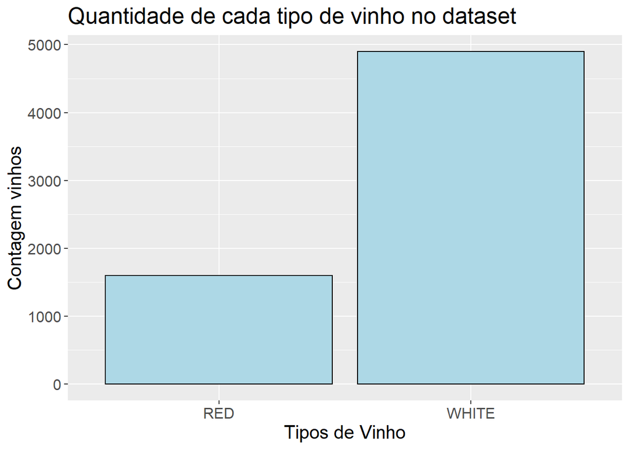

```r
# carregar pacote ggplot2
library(ggplot2)
# plotar um count plot com os numeros de cada dataset proporções e um grafico de pizza para a proporção
ggplot(data_vinhos2, aes(x = vinho)) + geom_bar(color= 'black', fill = 'lightblue') +
        labs(x = 'Tipos de Vinho', y = "Contagem vinhos",title = "Quantidade de cada tipo de vinho no dataset") +
        theme(text = element_text(size=15))
```

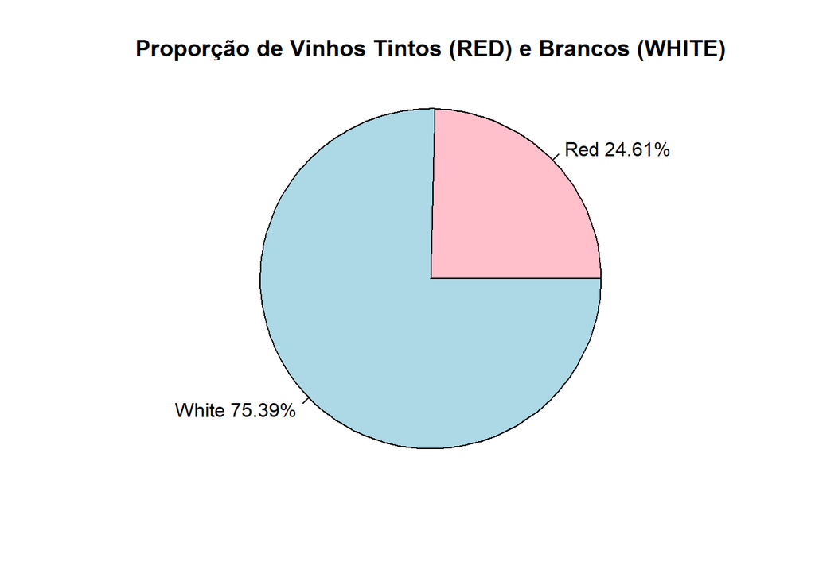

```r
lbls <- c('Red', 'White')
pct <- round(wine_proporcao*100,2)
lbls <- paste(lbls, pct) # add percents to labels
lbls <- paste(lbls,"%",sep="") # ad % to labels
pie(wine_proporcao, labels = lbls, radius = 1, col=c('pink', 'lightblue'),
    main="Proporção de Vinhos Tintos (RED) e Brancos (WHITE)") + theme(text = element_text(size=30))
```

```r
# função para plotar dois bloxpots lado a lado sendo um com informações dos vinhos tintos a esquerda e brancos a direita do plot
boxplot_plotar <- function(dataframe, variavel, nome) {
    return(ggplot() + geom_boxplot(aes(x=vinho, y = variavel)) +
    labs(x = 'Tipos de Vinho', y = nome ,title = "Vinho Tinto (RED) x Vinho Branco (WHITE)") +
    theme(text = element_text(size=17)))
}
```

```r
# função para exibir resumo da estatística descritiva
# uso do pacote moments para calculo da curtose e assimetria
library(moments)
describe_vinhos <- function(dataframe, name) {

    cat("Variável: ", name)
    summary(dataframe)
    cat("---Média:" , mean(dataframe), '---')
    cat("Desvio Padrão:", sd(dataframe), '---')
    cat("Mediana:", median(dataframe), '---')
    cat("Máximo:", max(dataframe),'---')
    cat("Mínimo:", min(dataframe),'---')
    cat("Range:", max(dataframe)-min(dataframe), '---')
    cat("Assimetria:", skewness(dataframe), '---')
    cat("Curtose:", kurtosis(dataframe))
}
```

```r
# função para detectar referência de outliers
outliers_detect <- function(dataframe, desv=3) {
  Q1 <- quantile(dataframe, 0.25)
  Q3 <- quantile(dataframe, 0.75)
  IQR <- Q3 - Q1
  max_outlier <- Q3 + desv*IQR
  min_outlier <- Q1 - desv*IQR
  cat('Outlier acima de: ',max_outlier, '--- ')
  cat('Outlier abaixo de: ',min_outlier)

}
```

```r
attach(data_vinhos2)
```

```r
# dimensão do dataset "red" vinhos tintos
dim(red)[1]
```

```
## [1] 1599
```

```r
# dimensão do dataset "white" vinhos brancos
dim(white)[1]
```

```
## [1] 4898
```

### Estatística descritiva das variáveis e estudo de outilers para vinhos tinhos e brancos

Nesta sessão serão analisadas diferenças entre as distribuições estatísticas de cada variável através do gráfico boxplot e inferencia estatística estatística com teste t-student (que curiosamente foi desenvolvido para avaliaçaõ da qualidade da cervejaria Guiness em Dublin, na Irlanda) para comparação entre as médias das variáveis para os dois tipos de vinho. Também será avaliado a ocorrência de outliers, utilizando o critério de 3 desvios. Os outliers identificados serão removidos das amostras para que estes não interfiram nos modelos de regressão, classificação e k-means.

#### Acidez Fixa

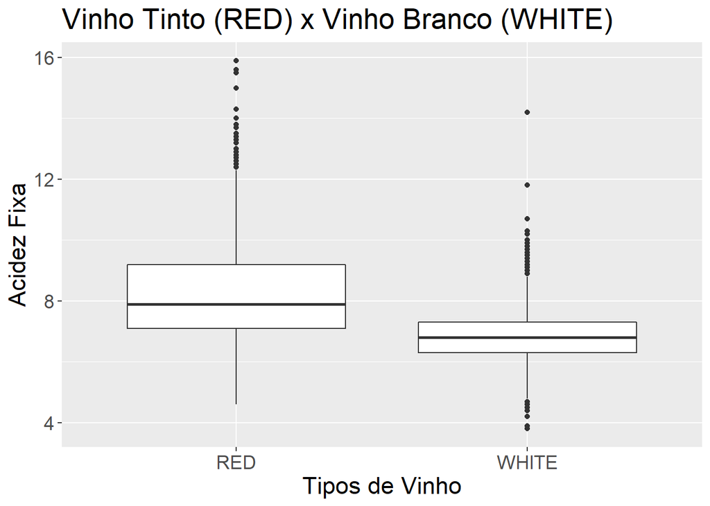

```r
boxplot_plotar(data_vinhos2, acidez_fixa, 'Acidez Fixa')
```

Estatísticas vinhos tintos:

```r
describe_vinhos(red$acidez_fixa, "Acidez Fixa")
```

```
## Variável:  Acidez Fixa---Média: 8.319637 ---Desvio Padrão: 1.741096 ---Mediana: 7.9 ---Máximo: 15.9 ---Mínimo: 4.6 ---Range: 11.3 ---Assimetria: 0.9818293 ---Curtose: 4.124856
```

Estatísticas vinhos brancos:

```r
describe_vinhos(white$acidez_fixa, "Acidez Fixa")
```

```
## Variável:  Acidez Fixa---Média: 6.854788 ---Desvio Padrão: 0.8438682 ---Mediana: 6.8 ---Máximo: 14.2 ---Mínimo: 3.8 ---Range: 10.4 ---Assimetria: 0.6475531 ---Curtose: 5.168737
```

**Vinhos Tintos** Acidez Fixa - Outliers

Valores de referência para outliers:

```r
outliers_detect(red$acidez_fixa)
```

```
## Outlier acima de:  15.5 --- Outlier abaixo de:  0.8
```

```r
# filtrar outliers acima
red %>% select (acidez_fixa) %>% filter (acidez_fixa > 15.5)
```

| acidez_fixa |
| --- |
| 15.6 |
| 15.6 |
| 15.9 |

3 registros acima e três desvios!

```r
# filtrar outliers abaixo
red %>% select (acidez_fixa) %>% filter (acidez_fixa < 0.8)
```

| acidez_fixa |
| --- |

Nenhum registro abaixo de três desvios

```r
# remover valores de acidez fixa acima de 15.5 e conferir
red <- red %>% filter (acidez_fixa <= 15.5)
dim(red)[1]
```

```
## [1] 1596
```

```r
head(red)
```

|  | acidez_fixa | acidez_volatil | acido_citrico | acucar_residual | cloretos | dioxido_de_enxofre_livre | dioxido_de_enxofre_total | densidade | pH | sulfatos | alcool | qualidade | vinho | vinhos_fator |
| --- | --- | --- | --- | --- | --- | --- | --- | --- | --- | --- | --- | --- | --- | --- |
| 1 | 10.6 | 0.310 | 0.49 | 2.2 | 0.063 | 18 | 40 | 0.99760 | 3.14 | 0.51 | 9.8 | 6 | RED | RED |
| 2 | 6.8 | 0.500 | 0.11 | 1.5 | 0.075 | 16 | 49 | 0.99545 | 3.36 | 0.79 | 9.5 | 5 | RED | RED |
| 3 | 6.6 | 0.610 | 0.00 | 1.6 | 0.069 | 4 | 8 | 0.99396 | 3.33 | 0.37 | 10.4 | 4 | RED | RED |
| 4 | 7.2 | 0.660 | 0.33 | 2.5 | 0.068 | 34 | 102 | 0.99414 | 3.27 | 0.78 | 12.8 | 6 | RED | RED |
| 5 | 7.2 | 0.630 | 0.00 | 1.9 | 0.097 | 14 | 38 | 0.99675 | 3.37 | 0.58 | 9.0 | 6 | RED | RED |
| 6 | 7.1 | 0.735 | 0.16 | 1.9 | 0.100 | 15 | 77 | 0.99660 | 3.27 | 0.64 | 9.3 | 5 | RED | RED |

**Vinhos Brancos** Acidez Fixa - Outliers

```r
outliers_detect(white$acidez_fixa)
```

```
## Outlier acima de:  10.3 --- Outlier abaixo de:  3.3
```

```r
# filtrar outliers acima
white %>% select (acidez_fixa) %>% filter (acidez_fixa > 10.3)
```

| acidez_fixa |
| --- |
| 10.7 |
| 11.8 |
| 14.2 |
| 10.7 |

4 registros encontrados acima de três desvios

```r
# filtrar outliers abaixo
white %>% select (acidez_fixa) %>% filter (acidez_fixa < 3.3)
```

| acidez_fixa |
| --- |

```r
# remover valores de acidez fixa acima de 10.3 e conferir
white <- white %>% filter (acidez_fixa <= 10.3)
dim(white)[1]
```

```
## [1] 4894
```

```r
head(white)
```

|  | acidez_fixa | acidez_volatil | acido_citrico | acucar_residual | cloretos | dioxido_de_enxofre_livre | dioxido_de_enxofre_total | densidade | pH | sulfatos | alcool | qualidade | vinho | vinhos_fator |
| --- | --- | --- | --- | --- | --- | --- | --- | --- | --- | --- | --- | --- | --- | --- |
| 1 | 6.6 | 0.24 | 0.35 | 7.70 | 0.031 | 36 | 135 | 0.99380 | 3.19 | 0.37 | 10.5 | 5 | WHITE | WHITE |
| 2 | 6.7 | 0.34 | 0.43 | 1.60 | 0.041 | 29 | 114 | 0.99014 | 3.23 | 0.44 | 12.6 | 6 | WHITE | WHITE |
| 3 | 5.4 | 0.18 | 0.24 | 4.80 | 0.041 | 30 | 113 | 0.99445 | 3.42 | 0.40 | 9.4 | 6 | WHITE | WHITE |
| 4 | 6.7 | 0.30 | 0.44 | 18.75 | 0.057 | 65 | 224 | 0.99956 | 3.11 | 0.53 | 9.1 | 5 | WHITE | WHITE |
| 5 | 5.1 | 0.26 | 0.33 | 1.10 | 0.027 | 46 | 113 | 0.98946 | 3.35 | 0.43 | 11.4 | 7 | WHITE | WHITE |
| 6 | 6.2 | 0.22 | 0.20 | 20.80 | 0.035 | 58 | 184 | 1.00022 | 3.11 | 0.53 | 9.0 | 6 | WHITE | WHITE |

Comparação das médias pelo teste t-student

```r
t.test(red$acidez_fixa, white$acidez_fixa, paired = FALSE, conf.level = 0.95, alternative = "two.sided")
```

```
##
##  Welch Two Sample t-test
##
## data:  red$acidez_fixa and white$acidez_fixa
## t = 32.702, df = 1845.7, p-value < 2.2e-16
## alternative hypothesis: true difference in means is not equal to 0
## 95 percent confidence interval:
##  1.367795 1.542324
## sample estimates:
## mean of x mean of y
##  8.305764  6.850705
```

Hipótese alternativa: As médias de acidez_fixa são diferentes para vinhos tintos e brancos? Conclusão: No teste t-student bicaudal foi constatado com 95% de confiança que rejeitamos a hipótese nula e aceitamos a hipótese alternativa. As médias não são iguais para vinhos tintos e brancos.

#### Acidez Volatil

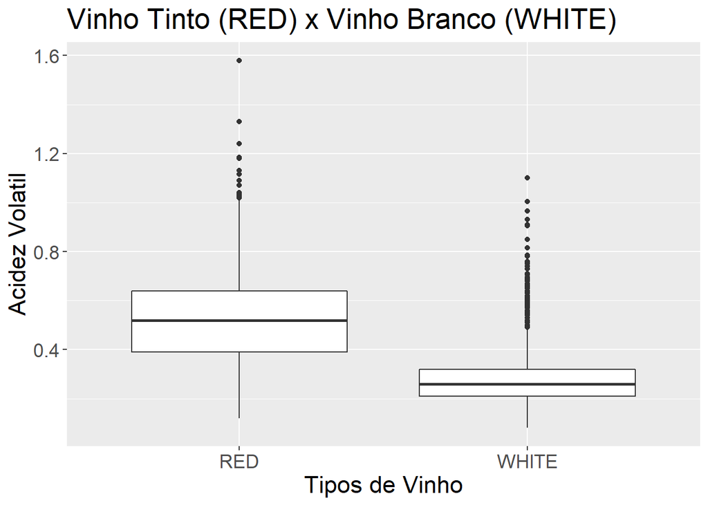

```r
boxplot_plotar(data_vinhos2, acidez_volatil, 'Acidez Volatil')
```

Estatísticas Vinhos Tintos:

```r
describe_vinhos(red$acidez_volatil, "Acidez Volatil")
```

```
## Variável:  Acidez Volatil---Média: 0.5277538 ---Desvio Padrão: 0.1791115 ---Mediana: 0.52 ---Máximo: 1.58 ---Mínimo: 0.12 ---Range: 1.46 ---Assimetria: 0.6726768 ---Curtose: 4.221049
```

Estatísticas Vinhos Brancos:

```r
describe_vinhos(white$acidez_volatil, "Acidez Volatil")
```

```
## Variável:  Acidez Volatil---Média: 0.2782765 ---Desvio Padrão: 0.1008264 ---Mediana: 0.26 ---Máximo: 1.1 ---Mínimo: 0.08 ---Range: 1.02 ---Assimetria: 1.575339 ---Curtose: 8.07932
```

**Vinhos Tintos** Acidez Volatil Outliers:

```r
outliers_detect(red$acidez_volatil)
```

```
## Outlier acima de:  1.39 --- Outlier abaixo de:  -0.36
```

```r
# filtrar outliers acima
red %>% select (acidez_volatil) %>% filter (acidez_volatil > 1.39)
```

| acidez_volatil |
| --- |
| 1.58 |

1 registro encontrado acima de 3 desvios

Sem outliers abaixo (acidez volatil não pode ser um valor negativo)

```r
# remover outlier
red <- red %>% filter (acidez_volatil <= 1.39)
dim(red)[1]
```

```
## [1] 1595
```

```r
head(red)
```

|  | acidez_fixa | acidez_volatil | acido_citrico | acucar_residual | cloretos | dioxido_de_enxofre_livre | dioxido_de_enxofre_total | densidade | pH | sulfatos | alcool | qualidade | vinho | vinhos_fator |
| --- | --- | --- | --- | --- | --- | --- | --- | --- | --- | --- | --- | --- | --- | --- |
| 1 | 10.6 | 0.310 | 0.49 | 2.2 | 0.063 | 18 | 40 | 0.99760 | 3.14 | 0.51 | 9.8 | 6 | RED | RED |
| 2 | 6.8 | 0.500 | 0.11 | 1.5 | 0.075 | 16 | 49 | 0.99545 | 3.36 | 0.79 | 9.5 | 5 | RED | RED |
| 3 | 6.6 | 0.610 | 0.00 | 1.6 | 0.069 | 4 | 8 | 0.99396 | 3.33 | 0.37 | 10.4 | 4 | RED | RED |
| 4 | 7.2 | 0.660 | 0.33 | 2.5 | 0.068 | 34 | 102 | 0.99414 | 3.27 | 0.78 | 12.8 | 6 | RED | RED |
| 5 | 7.2 | 0.630 | 0.00 | 1.9 | 0.097 | 14 | 38 | 0.99675 | 3.37 | 0.58 | 9.0 | 6 | RED | RED |
| 6 | 7.1 | 0.735 | 0.16 | 1.9 | 0.100 | 15 | 77 | 0.99660 | 3.27 | 0.64 | 9.3 | 5 | RED | RED |

**Vinhos Brancos** Acidez Volatil Outliers:

```r
outliers_detect(white$acidez_volatil)
```

```
## Outlier acima de:  0.65 --- Outlier abaixo de:  -0.12
```

```r
white %>% select (acidez_volatil) %>% filter (acidez_volatil > 0.65)
```

| acidez_volatil |
| --- |
| 0.695 |
| 0.670 |
| 0.710 |
| 0.660 |
| 0.910 |
| 0.660 |
| 0.690 |
| 0.670 |
| 0.690 |
| 0.670 |

[output cut: 29 more lines]

```r
# remover outilers
white <- white %>% filter (acidez_volatil <= 0.65)
dim(white)[1]
```

```
## [1] 4855
```

```r
head(white)
```

|  | acidez_fixa | acidez_volatil | acido_citrico | acucar_residual | cloretos | dioxido_de_enxofre_livre | dioxido_de_enxofre_total | densidade | pH | sulfatos | alcool | qualidade | vinho | vinhos_fator |
| --- | --- | --- | --- | --- | --- | --- | --- | --- | --- | --- | --- | --- | --- | --- |
| 1 | 6.6 | 0.24 | 0.35 | 7.70 | 0.031 | 36 | 135 | 0.99380 | 3.19 | 0.37 | 10.5 | 5 | WHITE | WHITE |
| 2 | 6.7 | 0.34 | 0.43 | 1.60 | 0.041 | 29 | 114 | 0.99014 | 3.23 | 0.44 | 12.6 | 6 | WHITE | WHITE |
| 3 | 5.4 | 0.18 | 0.24 | 4.80 | 0.041 | 30 | 113 | 0.99445 | 3.42 | 0.40 | 9.4 | 6 | WHITE | WHITE |
| 4 | 6.7 | 0.30 | 0.44 | 18.75 | 0.057 | 65 | 224 | 0.99956 | 3.11 | 0.53 | 9.1 | 5 | WHITE | WHITE |
| 5 | 5.1 | 0.26 | 0.33 | 1.10 | 0.027 | 46 | 113 | 0.98946 | 3.35 | 0.43 | 11.4 | 7 | WHITE | WHITE |
| 6 | 6.2 | 0.22 | 0.20 | 20.80 | 0.035 | 58 | 184 | 1.00022 | 3.11 | 0.53 | 9.0 | 6 | WHITE | WHITE |

Comparação das médias pelo teste t-student

```r
t.test(red$acidez_volatil, white$acidez_volatil, paired = FALSE, conf.level = 0.95, alternative = "two.sided")
```

```
##
##  Welch Two Sample t-test
##
## data:  red$acidez_volatil and white$acidez_volatil
## t = 54.574, df = 1881.3, p-value < 2.2e-16
## alternative hypothesis: true difference in means is not equal to 0
## 95 percent confidence interval:
##  0.2434892 0.2616422
## sample estimates:
## mean of x mean of y
## 0.5270940 0.2745283
```

Conclusão: A hipótese nula é rejeitada e hipótese alternativa “as médias são diferentes entre vinho tinto e branco” é aceita com 95% de significância

#### Acido Citrico

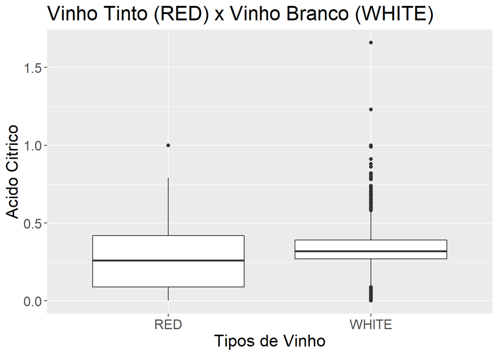

```r
boxplot_plotar(data_vinhos2, acido_citrico, 'Acido Citrico')
```

Estatísticas Vinhos Tintos

```r
describe_vinhos(red$acido_citrico, "Acido Cítrico")
```

```
## Variável:  Acido Cítrico---Média: 0.2704639 ---Desvio Padrão: 0.1942322 ---Mediana: 0.26 ---Máximo: 1 ---Mínimo: 0 ---Range: 1 ---Assimetria: 0.3156778 ---Curtose: 2.206903
```

Estatísticas Vinhos Brancos

```r
describe_vinhos(white$acido_citrico, "Acido Cítrico")
```

```
## Variável:  Acido Cítrico---Média: 0.3347168 ---Desvio Padrão: 0.1199619 ---Mediana: 0.32 ---Máximo: 1.66 ---Mínimo: 0 ---Range: 1.66 ---Assimetria: 1.338177 ---Curtose: 9.420321
```

**Vinhos Tintos** Acido Citrico - Outliers

```r
outliers_detect(red$acido_citrico)
```

```
## Outlier acima de:  1.41 --- Outlier abaixo de:  -0.9
```

```r
# filtrando outliers acima
red %>% select(acido_citrico) %>% filter(acido_citrico > 1.41)
```

| acido_citrico |
| --- |

Nenhum outlier para a variável ácido cítrico de vinhos tintos

**Vinhos Brancos**

```r
outliers_detect(white$acido_citrico)
```

```
## Outlier acima de:  0.75 --- Outlier abaixo de:  -0.09
```

```r
# filtrando outliers acima
white %>% select(acido_citrico) %>% filter(acido_citrico > 0.75)
```

| acido_citrico |
| --- |
| 1.00 |
| 1.00 |
| 0.88 |
| 0.91 |
| 0.79 |
| 0.81 |
| 0.82 |
| 0.99 |
| 1.66 |
| 0.79 |

[output cut: 12 more lines]

22 valores acima de 3 desvios para o acido cítitrico dos vinhos brancos

```r
# remover outliers
white <- white %>% filter(acido_citrico <= 0.75)
dim(white)[1]
```

```
## [1] 4833
```

Comparação das médias:

```r
t.test(red$acido_citrico, white$acido_citrico, paired = FALSE, conf.level = 0.95, alternative = "two.sided")
```

```
##
##  Welch Two Sample t-test
##
## data:  red$acido_citrico and white$acido_citrico
## t = -12.007, df = 1958.9, p-value < 2.2e-16
## alternative hypothesis: true difference in means is not equal to 0
## 95 percent confidence interval:
##  -0.07159986 -0.05149459
## sample estimates:
## mean of x mean of y
## 0.2704639 0.3320112
```

Conclusão: Rejeitamos a hipótese nula e aceitamos a hipótese alternativa (as médias são diferentes para o ácido cítrico de vinhos tintos e brancos com 95% de significancia)

#### Açucar Residual

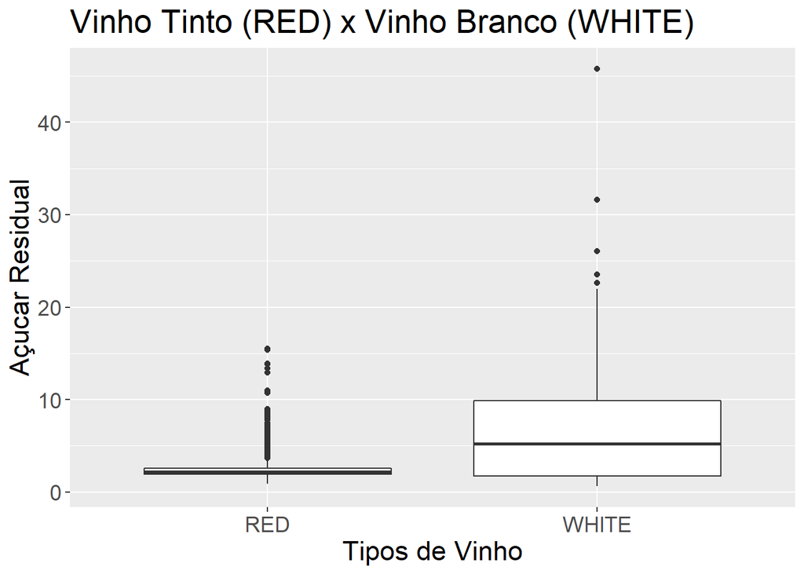

```r
boxplot_plotar(data_vinhos2, acucar_residual, 'Açucar Residual')
```

Estatísticas Vinhos Tintos:

```r
describe_vinhos(red$acucar_residual, "Açucar Residual")
```

```
## Variável:  Açucar Residual---Média: 2.534201 ---Desvio Padrão: 1.405249 ---Mediana: 2.2 ---Máximo: 15.5 ---Mínimo: 0.9 ---Range: 14.6 ---Assimetria: 4.574208 ---Curtose: 31.98747
```

Estatísticas Vinhos Brancos:

```r
describe_vinhos(white$acucar_residual, "Açucar Residual")
```

```
## Variável:  Açucar Residual---Média: 6.375047 ---Desvio Padrão: 4.995336 ---Mediana: 5.2 ---Máximo: 31.6 ---Mínimo: 0.6 ---Range: 31 ---Assimetria: 0.7880149 ---Curtose: 2.780426
```

**Vinhos Tintos** Açucar Residual - Outliers

```r
outliers_detect(red$acucar_residual)
```

```
## Outlier acima de:  4.7 --- Outlier abaixo de:  -0.2
```

```r
# filtrando outliers acima
red %>% select(acucar_residual) %>% filter(acucar_residual > 4.7)
```

| acucar_residual |
| --- |
| 5.60 |
| 5.80 |
| 5.50 |
| 5.90 |
| 7.90 |
| 5.10 |
| 12.90 |
| 7.00 |
| 6.00 |
| 5.60 |

[output cut: 77 more lines]

87 registros com açucar residual superior a 3 desvios

```r
# remover outliers
red <- red %>% filter(acucar_residual <= 4.7)
dim(red)[1]
```

```
## [1] 1508
```

```r
head(red)
```

|  | acidez_fixa | acidez_volatil | acido_citrico | acucar_residual | cloretos | dioxido_de_enxofre_livre | dioxido_de_enxofre_total | densidade | pH | sulfatos | alcool | qualidade | vinho | vinhos_fator |
| --- | --- | --- | --- | --- | --- | --- | --- | --- | --- | --- | --- | --- | --- | --- |
| 1 | 10.6 | 0.310 | 0.49 | 2.2 | 0.063 | 18 | 40 | 0.99760 | 3.14 | 0.51 | 9.8 | 6 | RED | RED |
| 2 | 6.8 | 0.500 | 0.11 | 1.5 | 0.075 | 16 | 49 | 0.99545 | 3.36 | 0.79 | 9.5 | 5 | RED | RED |
| 3 | 6.6 | 0.610 | 0.00 | 1.6 | 0.069 | 4 | 8 | 0.99396 | 3.33 | 0.37 | 10.4 | 4 | RED | RED |
| 4 | 7.2 | 0.660 | 0.33 | 2.5 | 0.068 | 34 | 102 | 0.99414 | 3.27 | 0.78 | 12.8 | 6 | RED | RED |
| 5 | 7.2 | 0.630 | 0.00 | 1.9 | 0.097 | 14 | 38 | 0.99675 | 3.37 | 0.58 | 9.0 | 6 | RED | RED |
| 6 | 7.1 | 0.735 | 0.16 | 1.9 | 0.100 | 15 | 77 | 0.99660 | 3.27 | 0.64 | 9.3 | 5 | RED | RED |

**Vinhos Brancos** Açucar residual - Outliers

```r
outliers_detect(white$acucar_residual)
```

```
## Outlier acima de:  34.5 --- Outlier abaixo de:  -22.9
```

```r
# filtrando outliers acima
white %>% select(acucar_residual) %>% filter(acucar_residual > 34.5)
```

| acucar_residual |
| --- |

Nenhum registro acima de 3 desvios para o açucar residual dos vinhos brancos.

Comparação das médias:

```r
t.test(red$acucar_residual, white$acucar_residual, paired = FALSE, conf.level = 0.95, alternative = "two.sided")
```

```
##
##  Welch Two Sample t-test
##
## data:  red$acucar_residual and white$acucar_residual
## t = -55.932, df = 5250.2, p-value < 2.2e-16
## alternative hypothesis: true difference in means is not equal to 0
## 95 percent confidence interval:
##  -4.254187 -3.966065
## sample estimates:
## mean of x mean of y
##  2.264920  6.375047
```

Conclusão: Rejeitamos a hipótese nula e aceitamos a hipótese alternativa (as médias de açucar residual são diferentes entre vinhos tintos e brancos com 95% de significancia)

#### Cloretos

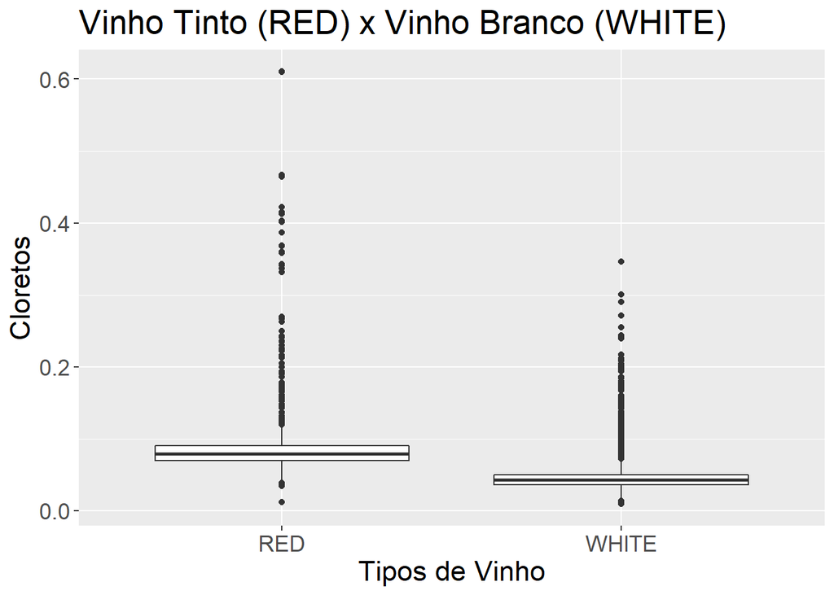

```r
boxplot_plotar(data_vinhos2, cloretos, 'Cloretos')
```

Estatísticas Vinhos Tintos:

```r
describe_vinhos(red$cloretos, "Cloretos")
```

```
## Variável:  Cloretos---Média: 0.08718302 ---Desvio Padrão: 0.04761152 ---Mediana: 0.079 ---Máximo: 0.611 ---Mínimo: 0.012 ---Range: 0.599 ---Assimetria: 5.762626 ---Curtose: 45.09367
```

Estatísticas Vinhos Brancos:

```r
describe_vinhos(white$cloretos, "Cloretos")
```

```
## Variável:  Cloretos---Média: 0.04555535 ---Desvio Padrão: 0.02111285 ---Mediana: 0.043 ---Máximo: 0.346 ---Mínimo: 0.009 ---Range: 0.337 ---Assimetria: 5.016346 ---Curtose: 41.41015
```

**Vinhos Tintos** Cloretos - Outliers

```r
outliers_detect(red$cloretos)
```

```
## Outlier acima de:  0.15 --- Outlier abaixo de:  0.01
```

```r
# filtrando outliers acima
red %>% select(cloretos) %>% filter(cloretos > 0.15)
```

| cloretos |
| --- |
| 0.414 |
| 0.415 |
| 0.174 |
| 0.172 |
| 0.165 |
| 0.337 |
| 0.263 |
| 0.267 |
| 0.414 |
| 0.178 |

[output cut: 51 more lines]

61 registros de cloretos acima de 3 desvios

```r
# filtrando outliers abaixo
red %>% select(cloretos) %>% filter(cloretos < 0.01)
```

| cloretos |
| --- |

```r
# removendo os outliers
red <- red %>% filter(cloretos <= 0.15)
dim(red)[1]
```

```
## [1] 1447
```

```r
head(red)
```

|  | acidez_fixa | acidez_volatil | acido_citrico | acucar_residual | cloretos | dioxido_de_enxofre_livre | dioxido_de_enxofre_total | densidade | pH | sulfatos | alcool | qualidade | vinho | vinhos_fator |
| --- | --- | --- | --- | --- | --- | --- | --- | --- | --- | --- | --- | --- | --- | --- |
| 1 | 10.6 | 0.310 | 0.49 | 2.2 | 0.063 | 18 | 40 | 0.99760 | 3.14 | 0.51 | 9.8 | 6 | RED | RED |
| 2 | 6.8 | 0.500 | 0.11 | 1.5 | 0.075 | 16 | 49 | 0.99545 | 3.36 | 0.79 | 9.5 | 5 | RED | RED |
| 3 | 6.6 | 0.610 | 0.00 | 1.6 | 0.069 | 4 | 8 | 0.99396 | 3.33 | 0.37 | 10.4 | 4 | RED | RED |
| 4 | 7.2 | 0.660 | 0.33 | 2.5 | 0.068 | 34 | 102 | 0.99414 | 3.27 | 0.78 | 12.8 | 6 | RED | RED |
| 5 | 7.2 | 0.630 | 0.00 | 1.9 | 0.097 | 14 | 38 | 0.99675 | 3.37 | 0.58 | 9.0 | 6 | RED | RED |
| 6 | 7.1 | 0.735 | 0.16 | 1.9 | 0.100 | 15 | 77 | 0.99660 | 3.27 | 0.64 | 9.3 | 5 | RED | RED |

**Vinhos Brancos** Cloretos - Outliers

```r
outliers_detect(white$cloretos)
```

```
## Outlier acima de:  0.092 --- Outlier abaixo de:  -0.006
```

```r
# filtrando outliers acima
white %>% select(cloretos) %>% filter(cloretos > 0.092)
```

| cloretos |
| --- |
| 0.114 |
| 0.093 |
| 0.172 |
| 0.171 |
| 0.147 |
| 0.123 |
| 0.168 |
| 0.144 |
| 0.126 |
| 0.115 |

[output cut: 112 more lines]

122 registros de cloretos acima de 3 desvios

```r
# removendo outliers
white <- white %>% filter(cloretos <= 0.092)
dim(white)[1]
```

```
## [1] 4711
```

```r
head(white)
```

|  | acidez_fixa | acidez_volatil | acido_citrico | acucar_residual | cloretos | dioxido_de_enxofre_livre | dioxido_de_enxofre_total | densidade | pH | sulfatos | alcool | qualidade | vinho | vinhos_fator |
| --- | --- | --- | --- | --- | --- | --- | --- | --- | --- | --- | --- | --- | --- | --- |
| 1 | 6.6 | 0.24 | 0.35 | 7.70 | 0.031 | 36 | 135 | 0.99380 | 3.19 | 0.37 | 10.5 | 5 | WHITE | WHITE |
| 2 | 6.7 | 0.34 | 0.43 | 1.60 | 0.041 | 29 | 114 | 0.99014 | 3.23 | 0.44 | 12.6 | 6 | WHITE | WHITE |
| 3 | 5.4 | 0.18 | 0.24 | 4.80 | 0.041 | 30 | 113 | 0.99445 | 3.42 | 0.40 | 9.4 | 6 | WHITE | WHITE |
| 4 | 6.7 | 0.30 | 0.44 | 18.75 | 0.057 | 65 | 224 | 0.99956 | 3.11 | 0.53 | 9.1 | 5 | WHITE | WHITE |
| 5 | 5.1 | 0.26 | 0.33 | 1.10 | 0.027 | 46 | 113 | 0.98946 | 3.35 | 0.43 | 11.4 | 7 | WHITE | WHITE |
| 6 | 6.2 | 0.22 | 0.20 | 20.80 | 0.035 | 58 | 184 | 1.00022 | 3.11 | 0.53 | 9.0 | 6 | WHITE | WHITE |

Comparação das médias:

```r
t.test(red$cloretos, white$cloretos, paired = FALSE, conf.level = 0.95, alternative = "two.sided")
```

```
##
##  Welch Two Sample t-test
##
## data:  red$cloretos and white$cloretos
## t = 78.372, df = 1844.1, p-value < 2.2e-16
## alternative hypothesis: true difference in means is not equal to 0
## 95 percent confidence interval:
##  0.03557776 0.03740413
## sample estimates:
##  mean of x  mean of y
## 0.07937526 0.04288431
```

Conclusão: Rejeitamos a hipótese nula e aceitamos a hipótese alternativa (as médias de cloretos entre vinhos tintos e brancos é diferente com 95% de significancia)

#### Dioxido de Enxofre Livre

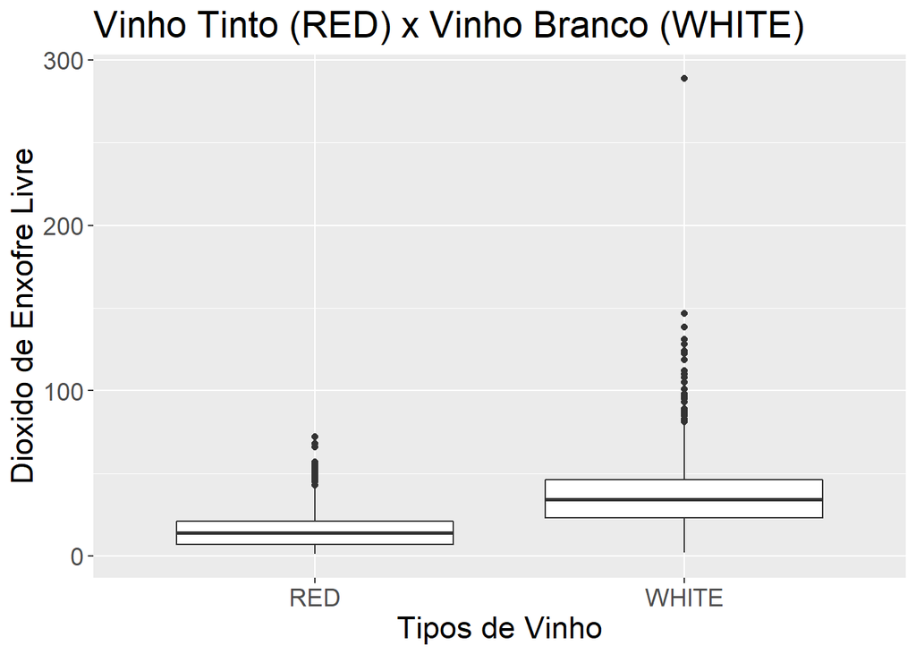

```r
boxplot_plotar(data_vinhos2, dioxido_de_enxofre_livre , 'Dioxido de Enxofre Livre')
```

Estatísticas Vinhos Tintos:

```r
describe_vinhos(red$dioxido_de_enxofre_livre, "Dioxido de Enxofre Livre")
```

```
## Variável:  Dioxido de Enxofre Livre---Média: 15.67899 ---Desvio Padrão: 9.814607 ---Mediana: 14 ---Máximo: 57 ---Mínimo: 1 ---Range: 56 ---Assimetria: 0.9993921 ---Curtose: 3.710505
```

Estatísticas Vinhos Brancos:

```r
describe_vinhos(white$dioxido_de_enxofre_livre, "Dioxido de Enxofre Livre")
```

```
## Variável:  Dioxido de Enxofre Livre---Média: 35.28051 ---Desvio Padrão: 16.96234 ---Mediana: 34 ---Máximo: 289 ---Mínimo: 2 ---Range: 287 ---Assimetria: 1.454286 ---Curtose: 15.07293
```

**Vinhos Tintos** Dioxido de Enxofre - Outliers

```r
outliers_detect(red$dioxido_de_enxofre_livre)
```

```
## Outlier acima de:  60 --- Outlier abaixo de:  -31
```

```r
red %>% select(dioxido_de_enxofre_livre) %>% filter(dioxido_de_enxofre_livre > 60)
```

| dioxido_de_enxofre_livre |
| --- |

Sem registros acima de 3 desvios para dioxido de enxofre livre dos vinhos tintos

```r
outliers_detect(white$dioxido_de_enxofre_livre)
```

```
## Outlier acima de:  115 --- Outlier abaixo de:  -46
```

```r
white %>% select(dioxido_de_enxofre_livre) %>% filter(dioxido_de_enxofre_livre > 115)
```

| dioxido_de_enxofre_livre |
| --- |
| 289.0 |
| 128.0 |
| 122.5 |
| 146.5 |
| 131.0 |
| 124.0 |
| 138.5 |
| 118.5 |

```r
# remover outliers
white <- white %>% filter(dioxido_de_enxofre_livre <= 115)
dim(white)[1]
```

```
## [1] 4703
```

```r
head(white)
```

|  | acidez_fixa | acidez_volatil | acido_citrico | acucar_residual | cloretos | dioxido_de_enxofre_livre | dioxido_de_enxofre_total | densidade | pH | sulfatos | alcool | qualidade | vinho | vinhos_fator |
| --- | --- | --- | --- | --- | --- | --- | --- | --- | --- | --- | --- | --- | --- | --- |
| 1 | 6.6 | 0.24 | 0.35 | 7.70 | 0.031 | 36 | 135 | 0.99380 | 3.19 | 0.37 | 10.5 | 5 | WHITE | WHITE |
| 2 | 6.7 | 0.34 | 0.43 | 1.60 | 0.041 | 29 | 114 | 0.99014 | 3.23 | 0.44 | 12.6 | 6 | WHITE | WHITE |
| 3 | 5.4 | 0.18 | 0.24 | 4.80 | 0.041 | 30 | 113 | 0.99445 | 3.42 | 0.40 | 9.4 | 6 | WHITE | WHITE |
| 4 | 6.7 | 0.30 | 0.44 | 18.75 | 0.057 | 65 | 224 | 0.99956 | 3.11 | 0.53 | 9.1 | 5 | WHITE | WHITE |
| 5 | 5.1 | 0.26 | 0.33 | 1.10 | 0.027 | 46 | 113 | 0.98946 | 3.35 | 0.43 | 11.4 | 7 | WHITE | WHITE |
| 6 | 6.2 | 0.22 | 0.20 | 20.80 | 0.035 | 58 | 184 | 1.00022 | 3.11 | 0.53 | 9.0 | 6 | WHITE | WHITE |

Comparação das médias

```r
t.test(red$dioxido_de_enxofre_livre, white$dioxido_de_enxofre_livre, paired = FALSE, conf.level = 0.95, alternative = "two.sided")
```

```
##
##  Welch Two Sample t-test
##
## data:  red$dioxido_de_enxofre_livre and white$dioxido_de_enxofre_livre
## t = -55.544, df = 4006.1, p-value < 2.2e-16
## alternative hypothesis: true difference in means is not equal to 0
## 95 percent confidence interval:
##  -20.09181 -18.72180
## sample estimates:
## mean of x mean of y
##  15.67899  35.08580
```

Conclusão: Rejeitamos a hipótese nula e aceitamos a hipótese alternativa (as médias de dioxido de enxofre livre entre vinhos tintos e brancos é diferente com 95% de significancia)

#### Dioxido de Enxofre Total

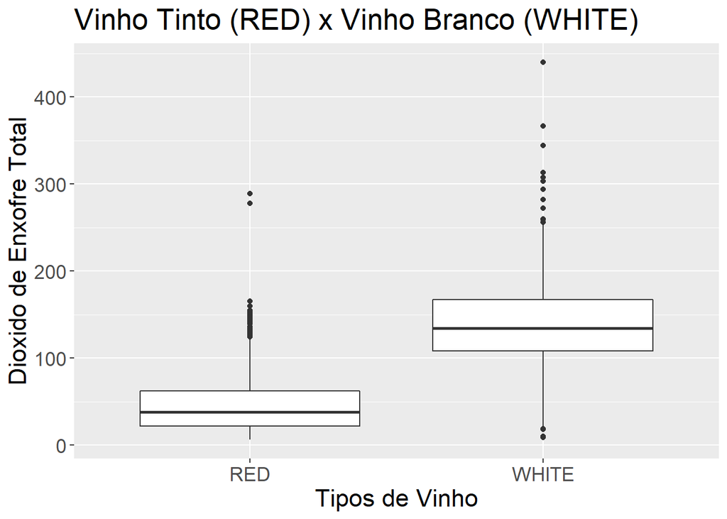

```r
boxplot_plotar(data_vinhos2, dioxido_de_enxofre_total, 'Dioxido de Enxofre Total')
```

Estatísticas Vinhos Tintos:

```r
describe_vinhos(red$dioxido_de_enxofre_total, "Dioxido de Enxofre Total")
```

```
## Variável:  Dioxido de Enxofre Total---Média: 45.17415 ---Desvio Padrão: 30.74595 ---Mediana: 37 ---Máximo: 165 ---Mínimo: 6 ---Range: 159 ---Assimetria: 1.2334 ---Curtose: 4.16539
```

Estatísticas Vinhos Brancos:

```r
describe_vinhos(white$dioxido_de_enxofre_total, "Dioxido de Enxofre Total")
```

```
## Variável:  Dioxido de Enxofre Total---Média: 137.8815 ---Desvio Padrão: 41.80834 ---Mediana: 134 ---Máximo: 366.5 ---Mínimo: 10 ---Range: 356.5 ---Assimetria: 0.3179738 ---Curtose: 3.055455
```

**Vinhos Tintos** Dioxido de Enxofre Total - Outliers

```r
outliers_detect(red$dioxido_de_enxofre_total)
```

```
## Outlier acima de:  174 --- Outlier abaixo de:  -92
```

```r
# filtrando valores acima
red %>% select(dioxido_de_enxofre_total) %>% filter(dioxido_de_enxofre_total > 174)
```

| dioxido_de_enxofre_total |
| --- |

**Vinhos Brancos** Dioxido de Enxofre Total - Outliers

```r
outliers_detect(white$dioxido_de_enxofre_total)
```

```
## Outlier acima de:  344 --- Outlier abaixo de:  -69
```

```r
# filtrando outliers acima
white %>% select(dioxido_de_enxofre_total) %>% filter(dioxido_de_enxofre_total > 344)
```

| dioxido_de_enxofre_total |
| --- |
| 366.5 |

1 registro acima de 3 desvios para dioxido de enxofre total dos vinhos brancos

```r
# removendo o outlier
white <- white %>% filter(dioxido_de_enxofre_total <= 344)
dim(white)[1]
```

```
## [1] 4702
```

```r
head(white)
```

|  | acidez_fixa | acidez_volatil | acido_citrico | acucar_residual | cloretos | dioxido_de_enxofre_livre | dioxido_de_enxofre_total | densidade | pH | sulfatos | alcool | qualidade | vinho | vinhos_fator |
| --- | --- | --- | --- | --- | --- | --- | --- | --- | --- | --- | --- | --- | --- | --- |
| 1 | 6.6 | 0.24 | 0.35 | 7.70 | 0.031 | 36 | 135 | 0.99380 | 3.19 | 0.37 | 10.5 | 5 | WHITE | WHITE |
| 2 | 6.7 | 0.34 | 0.43 | 1.60 | 0.041 | 29 | 114 | 0.99014 | 3.23 | 0.44 | 12.6 | 6 | WHITE | WHITE |
| 3 | 5.4 | 0.18 | 0.24 | 4.80 | 0.041 | 30 | 113 | 0.99445 | 3.42 | 0.40 | 9.4 | 6 | WHITE | WHITE |
| 4 | 6.7 | 0.30 | 0.44 | 18.75 | 0.057 | 65 | 224 | 0.99956 | 3.11 | 0.53 | 9.1 | 5 | WHITE | WHITE |
| 5 | 5.1 | 0.26 | 0.33 | 1.10 | 0.027 | 46 | 113 | 0.98946 | 3.35 | 0.43 | 11.4 | 7 | WHITE | WHITE |
| 6 | 6.2 | 0.22 | 0.20 | 20.80 | 0.035 | 58 | 184 | 1.00022 | 3.11 | 0.53 | 9.0 | 6 | WHITE | WHITE |

Comparação das médias:

```r
t.test(red$dioxido_de_enxofre_total, white$dioxido_de_enxofre_total, paired = FALSE, conf.level = 0.95, alternative = "two.sided")
```

```
##
##  Welch Two Sample t-test
##
## data:  red$dioxido_de_enxofre_total and white$dioxido_de_enxofre_total
## t = -91.622, df = 3226.6, p-value < 2.2e-16
## alternative hypothesis: true difference in means is not equal to 0
## 95 percent confidence interval:
##  -94.64156 -90.67581
## sample estimates:
## mean of x mean of y
##  45.17415 137.83284
```

Conclusão: Rejeitamos a hipótese nula e aceitamos a hipótese alternativa (as médias de dioxido de enxofre total entre vinhos tintos e brancos é diferente com 95% de significancia)

#### Densidade

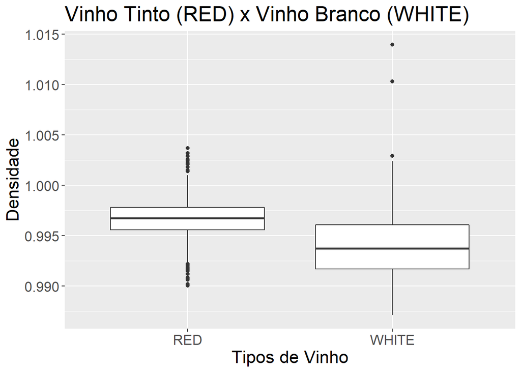

```r
boxplot_plotar(data_vinhos, densidade, 'Densidade')
```

Estatísticas Vinhos Tintos:

```r
describe_vinhos(red$densidade, 'Densidade')
```

```
## Variável:  Densidade---Média: 0.9966281 ---Desvio Padrão: 0.001818536 ---Mediana: 0.99664 ---Máximo: 1.00315 ---Mínimo: 0.99007 ---Range: 0.01308 ---Assimetria: -0.1115135 ---Curtose: 3.669549
```

Estatísticas Vinhos Brancos:

```r
describe_vinhos(white$densidade, 'Densidade')
```

```
## Variável:  Densidade---Média: 0.9939913 ---Desvio Padrão: 0.002934599 ---Mediana: 0.9937 ---Máximo: 1.0103 ---Mínimo: 0.98711 ---Range: 0.02319 ---Assimetria: 0.3287554 ---Curtose: 2.591001
```

Conclusão: Valor de densidade próximo ao da água para os dois tipos de vinho. Não usar esta variável para geração de modelos.

#### pH

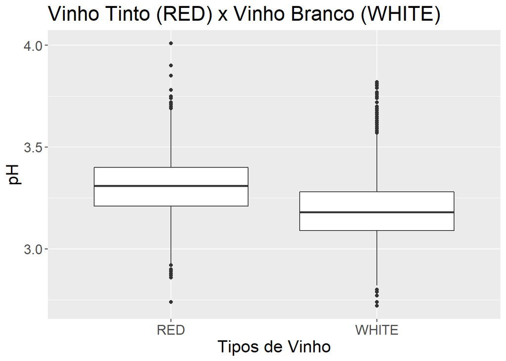

```r
boxplot_plotar(data_vinhos2, pH, 'pH')
```

Estatísticas Vinhos Tintos:

```r
describe_vinhos(red$pH, "pH")
```

```
## Variável:  pH---Média: 3.31774 ---Desvio Padrão: 0.1529315 ---Mediana: 3.31 ---Máximo: 4.01 ---Mínimo: 2.86 ---Range: 1.15 ---Assimetria: 0.2477968 ---Curtose: 3.841995
```

Estatísticas Vinhos Brancos:

```r
describe_vinhos(white$pH, "pH")
```

```
## Variável:  pH---Média: 3.190617 ---Desvio Padrão: 0.1506552 ---Mediana: 3.18 ---Máximo: 3.82 ---Mínimo: 2.72 ---Range: 1.1 ---Assimetria: 0.4513815 ---Curtose: 3.555599
```

**Vinhos Tintos** pH - Outliers

```r
outliers_detect(red$pH)
```

```
## Outlier acima de:  3.98 --- Outlier abaixo de:  2.65
```

```r
# filtrando outliers acima
red %>% select(pH) %>% filter(pH > 3.98)
```

| pH |
| --- |
| 4.01 |
| 4.01 |

2 registros de pH acima de 3 desvios para vinhos tintos

```r
# filtrando outliers abaixo
red %>% select(pH) %>% filter(pH < 2.65)
```

| pH |
| --- |

```r
# removendo outliers
red <- red %>% filter(pH <= 3.98)
dim(red)[1]
```

```
## [1] 1445
```

```r
head(red)
```

|  | acidez_fixa | acidez_volatil | acido_citrico | acucar_residual | cloretos | dioxido_de_enxofre_livre | dioxido_de_enxofre_total | densidade | pH | sulfatos | alcool | qualidade | vinho | vinhos_fator |
| --- | --- | --- | --- | --- | --- | --- | --- | --- | --- | --- | --- | --- | --- | --- |
| 1 | 10.6 | 0.310 | 0.49 | 2.2 | 0.063 | 18 | 40 | 0.99760 | 3.14 | 0.51 | 9.8 | 6 | RED | RED |
| 2 | 6.8 | 0.500 | 0.11 | 1.5 | 0.075 | 16 | 49 | 0.99545 | 3.36 | 0.79 | 9.5 | 5 | RED | RED |
| 3 | 6.6 | 0.610 | 0.00 | 1.6 | 0.069 | 4 | 8 | 0.99396 | 3.33 | 0.37 | 10.4 | 4 | RED | RED |
| 4 | 7.2 | 0.660 | 0.33 | 2.5 | 0.068 | 34 | 102 | 0.99414 | 3.27 | 0.78 | 12.8 | 6 | RED | RED |
| 5 | 7.2 | 0.630 | 0.00 | 1.9 | 0.097 | 14 | 38 | 0.99675 | 3.37 | 0.58 | 9.0 | 6 | RED | RED |
| 6 | 7.1 | 0.735 | 0.16 | 1.9 | 0.100 | 15 | 77 | 0.99660 | 3.27 | 0.64 | 9.3 | 5 | RED | RED |

**Vinhos Brancos** pH - Outliers

```r
outliers_detect(white$pH)
```

```
## Outlier acima de:  3.85 --- Outlier abaixo de:  2.52
```

```r
# filtrando outliers acima
white %>% select(pH) %>% filter(pH > 3.85)
```

| pH |
| --- |

```r
# filtrando outliers abaixo
white %>% select(pH) %>% filter(pH < 2.52)
```

| pH |
| --- |

sem outliers para o ph de vinhos brancos

Comparação das Médias:

```r
t.test(red$pH, white$pH, paired = FALSE, conf.level = 0.95, alternative = "two.sided")
```

```
##
##  Welch Two Sample t-test
##
## data:  red$pH and white$pH
## t = 27.814, df = 2395.8, p-value < 2.2e-16
## alternative hypothesis: true difference in means is not equal to 0
## 95 percent confidence interval:
##  0.1172704 0.1350601
## sample estimates:
## mean of x mean of y
##  3.316782  3.190617
```

Conclusão: Rejeitamos a hipótese nula e aceitamos a hipótese alternativa (as médias de pH entre vinhos tintos e brancos é diferente com 95% de significancia)

#### Sulfatos

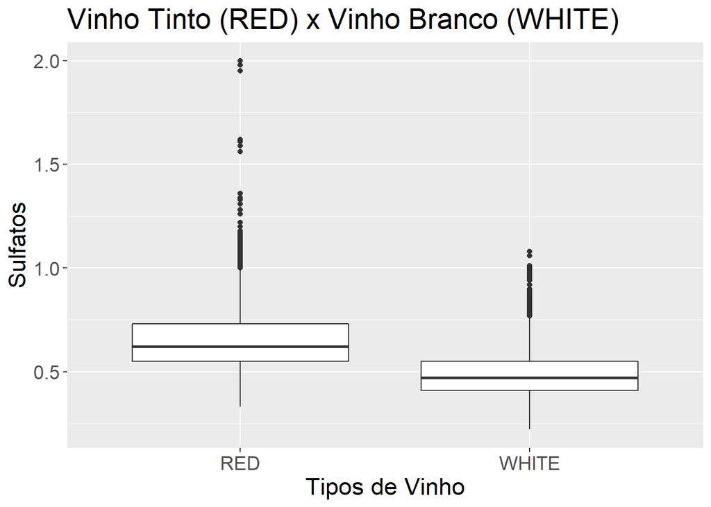

```r
boxplot_plotar(data_vinhos2, sulfatos, 'Sulfatos')
```

Estatísticas Vinhos Tintos:

```r
describe_vinhos(red$sulfatos, 'Sulfatos')
```

```
## Variável:  Sulfatos---Média: 0.6473702 ---Desvio Padrão: 0.1536369 ---Mediana: 0.62 ---Máximo: 1.98 ---Mínimo: 0.33 ---Range: 1.65 ---Assimetria: 2.407671 ---Curtose: 16.46999
```

Estatísticas Vinhos Brancos:

```r
describe_vinhos(white$sulfatos, 'Sulfatos')
```

```
## Variável:  Sulfatos---Média: 0.4899575 ---Desvio Padrão: 0.1142548 ---Mediana: 0.47 ---Máximo: 1.08 ---Mínimo: 0.22 ---Range: 0.86 ---Assimetria: 0.9636959 ---Curtose: 4.519565
```

**Vinhos Tintos** Sulfatos - Outliers

```r
outliers_detect(red$sulfatos)
```

```
## Outlier acima de:  1.23 --- Outlier abaixo de:  0.04
```

```r
# filtrando outliers acima
red %>% select(sulfatos) %>% filter(sulfatos > 1.23)
```

| sulfatos |
| --- |
| 1.36 |
| 1.62 |
| 1.36 |
| 1.98 |
| 1.56 |
| 1.36 |
| 1.95 |
| 1.95 |

8 registros de sulfatos acima de 3 desvios para vinhos tintos

```r
# filtrando outliers abaixo
red %>% select(sulfatos) %>% filter(sulfatos < 0.04)
```

| sulfatos |
| --- |

```r
# removendo outliers
red <- red %>% filter(sulfatos <= 1.23)
dim(red)[1]
```

```
## [1] 1437
```

```r
head(red)
```

|  | acidez_fixa | acidez_volatil | acido_citrico | acucar_residual | cloretos | dioxido_de_enxofre_livre | dioxido_de_enxofre_total | densidade | pH | sulfatos | alcool | qualidade | vinho | vinhos_fator |
| --- | --- | --- | --- | --- | --- | --- | --- | --- | --- | --- | --- | --- | --- | --- |
| 1 | 10.6 | 0.310 | 0.49 | 2.2 | 0.063 | 18 | 40 | 0.99760 | 3.14 | 0.51 | 9.8 | 6 | RED | RED |
| 2 | 6.8 | 0.500 | 0.11 | 1.5 | 0.075 | 16 | 49 | 0.99545 | 3.36 | 0.79 | 9.5 | 5 | RED | RED |
| 3 | 6.6 | 0.610 | 0.00 | 1.6 | 0.069 | 4 | 8 | 0.99396 | 3.33 | 0.37 | 10.4 | 4 | RED | RED |
| 4 | 7.2 | 0.660 | 0.33 | 2.5 | 0.068 | 34 | 102 | 0.99414 | 3.27 | 0.78 | 12.8 | 6 | RED | RED |
| 5 | 7.2 | 0.630 | 0.00 | 1.9 | 0.097 | 14 | 38 | 0.99675 | 3.37 | 0.58 | 9.0 | 6 | RED | RED |
| 6 | 7.1 | 0.735 | 0.16 | 1.9 | 0.100 | 15 | 77 | 0.99660 | 3.27 | 0.64 | 9.3 | 5 | RED | RED |

**Vinhos Brancos** Sulfatos - Outliers

```r
outliers_detect(white$sulfatos)
```

```
## Outlier acima de:  0.97 --- Outlier abaixo de:  -0.01
```

```r
# filtrando outliers acima
white %>% select(sulfatos) %>% filter(sulfatos > 0.97)
```

| sulfatos |
| --- |
| 0.98 |
| 0.98 |
| 0.98 |
| 1.06 |
| 1.08 |
| 0.98 |
| 0.98 |
| 0.99 |
| 1.01 |
| 0.98 |

10 registros acima de 3 desvios para os sulfatos dos vinhos brancos

```r
# removendo outliers
white <- white %>% filter(sulfatos <= 0.97)
dim(white)[1]
```

```
## [1] 4692
```

```r
head(white)
```

|  | acidez_fixa | acidez_volatil | acido_citrico | acucar_residual | cloretos | dioxido_de_enxofre_livre | dioxido_de_enxofre_total | densidade | pH | sulfatos | alcool | qualidade | vinho | vinhos_fator |
| --- | --- | --- | --- | --- | --- | --- | --- | --- | --- | --- | --- | --- | --- | --- |
| 1 | 6.6 | 0.24 | 0.35 | 7.70 | 0.031 | 36 | 135 | 0.99380 | 3.19 | 0.37 | 10.5 | 5 | WHITE | WHITE |
| 2 | 6.7 | 0.34 | 0.43 | 1.60 | 0.041 | 29 | 114 | 0.99014 | 3.23 | 0.44 | 12.6 | 6 | WHITE | WHITE |
| 3 | 5.4 | 0.18 | 0.24 | 4.80 | 0.041 | 30 | 113 | 0.99445 | 3.42 | 0.40 | 9.4 | 6 | WHITE | WHITE |
| 4 | 6.7 | 0.30 | 0.44 | 18.75 | 0.057 | 65 | 224 | 0.99956 | 3.11 | 0.53 | 9.1 | 5 | WHITE | WHITE |
| 5 | 5.1 | 0.26 | 0.33 | 1.10 | 0.027 | 46 | 113 | 0.98946 | 3.35 | 0.43 | 11.4 | 7 | WHITE | WHITE |
| 6 | 6.2 | 0.22 | 0.20 | 20.80 | 0.035 | 58 | 184 | 1.00022 | 3.11 | 0.53 | 9.0 | 6 | WHITE | WHITE |

Comparação das médias:

```r
t.test(red$sulfatos, white$sulfatos, paired = FALSE, conf.level = 0.95, alternative = "two.sided")
```

```
##
##  Welch Two Sample t-test
##
## data:  red$sulfatos and white$sulfatos
## t = 39.418, df = 2091.4, p-value < 2.2e-16
## alternative hypothesis: true difference in means is not equal to 0
## 95 percent confidence interval:
##  0.1453539 0.1605742
## sample estimates:
## mean of x mean of y
## 0.6418302 0.4888662
```

Conclusão: Rejeitamos a hipótese nula e aceitamos a hipótese alternativa (as médias de sulfatos entre vinhos tintos e brancos é diferente com 95% de significancia)

#### Álcool

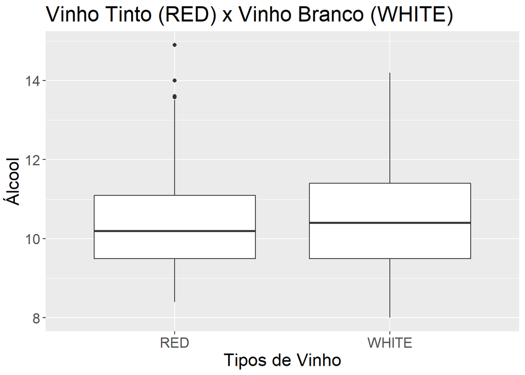

```r
boxplot_plotar(data_vinhos2, alcool, 'Álcool')
```

Estatísticas Vinhos Tintos:

```r
describe_vinhos(red$alcool, 'Álcool')
```

```
## Variável:  Álcool---Média: 10.43889 ---Desvio Padrão: 1.054147 ---Mediana: 10.2 ---Máximo: 14 ---Mínimo: 8.4 ---Range: 5.6 ---Assimetria: 0.8450536 ---Curtose: 3.107343
```

Estatísticas Vinhos Brancos:

```r
describe_vinhos(white$alcool, 'Álcool')
```

```
## Variável:  Álcool---Média: 10.53696 ---Desvio Padrão: 1.22902 ---Mediana: 10.4 ---Máximo: 14.2 ---Mínimo: 8 ---Range: 6.2 ---Assimetria: 0.4540014 ---Curtose: 2.279167
```

**Vinhos Tintos** Alcool - Outliers

```r
outliers_detect(red$alcool)
```

```
## Outlier acima de:  15.9 --- Outlier abaixo de:  4.7
```

```r
# filtrando outliers acima
red %>% select(alcool) %>% filter (alcool > 15.9)
```

| alcool |
| --- |

Nenhum valor outlier para álcool dos vinhos tintos. Lembrando que foi consertado uma inconsistência nos dados mais acima neste relatório

**Vinhos Brancos** Alcool - Outliers

```r
outliers_detect(white$alcool)
```

```
## Outlier acima de:  17.1 --- Outlier abaixo de:  3.8
```

```r
white %>% select(alcool) %>% filter (alcool > 17.1)
```

| alcool |
| --- |

Comparação das Médias:

```r
t.test(red$alcool, white$alcool, paired = FALSE, conf.level = 0.95, alternative = "two.sided")
```

```
##
##  Welch Two Sample t-test
##
## data:  red$alcool and white$alcool
## t = -2.9635, df = 2735.4, p-value = 0.003068
## alternative hypothesis: true difference in means is not equal to 0
## 95 percent confidence interval:
##  -0.16296614 -0.03318191
## sample estimates:
## mean of x mean of y
##  10.43889  10.53696
```

Conclusão: Rejeitamos a hipótese nula e aceitamos a hipótese alternativa (as médias de teor alcóolico entre vinhos tintos e brancos é diferente com 95% de significancia)

#### Qualidade

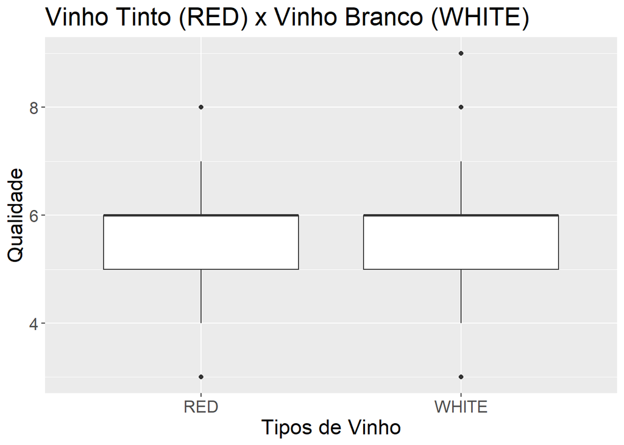

```r
boxplot_plotar(data_vinhos2, qualidade, 'Qualidade')
```

Estatística Vinhos Tintos:

```r
describe_vinhos(red$qualidade, 'Qualidade')
```

```
## Variável:  Qualidade---Média: 5.643006 ---Desvio Padrão: 0.7959955 ---Mediana: 6 ---Máximo: 8 ---Mínimo: 3 ---Range: 5 ---Assimetria: 0.2635717 ---Curtose: 3.205043
```

Estatística Vinhos Brancos:

```r
describe_vinhos(white$qualidade, 'Qualidade')
```

```
## Variável:  Qualidade---Média: 5.901321 ---Desvio Padrão: 0.8776473 ---Mediana: 6 ---Máximo: 9 ---Mínimo: 3 ---Range: 6 ---Assimetria: 0.1870708 ---Curtose: 3.138626
```

A variável qualidade é a variável alvo para os modelos de regressão linear multipla e regressão logística, portanto, não será realizado o estudo de outliers para esta variável para nenhum dos vinhos

Aqui queremos testar se podemos afirmar que: A média da qualidade dos vinhos tintos é superior a dos vinhos brancos neste dataset?

```r
t.test(red$qualidade, white$qualidade, paired = FALSE, conf.level = 0.95, alternative = "greater")
```

```
##
##  Welch Two Sample t-test
##
## data:  red$qualidade and white$qualidade
## t = -10.501, df = 2594.3, p-value = 1
## alternative hypothesis: true difference in means is greater than 0
## 95 percent confidence interval:
##  -0.2987907        Inf
## sample estimates:
## mean of x mean of y
##  5.643006  5.901321
```

Conclusao: **Falhamos em rejeitar a hipótese nula**. Não podemos afirmar **com 95% de significancia** que a média dos vinhos tintos é superior a média dos vinhos brancos.

### 4. Correlação entre as variáveis

```r
library(GGally)
```

#### Vinhos Tintos

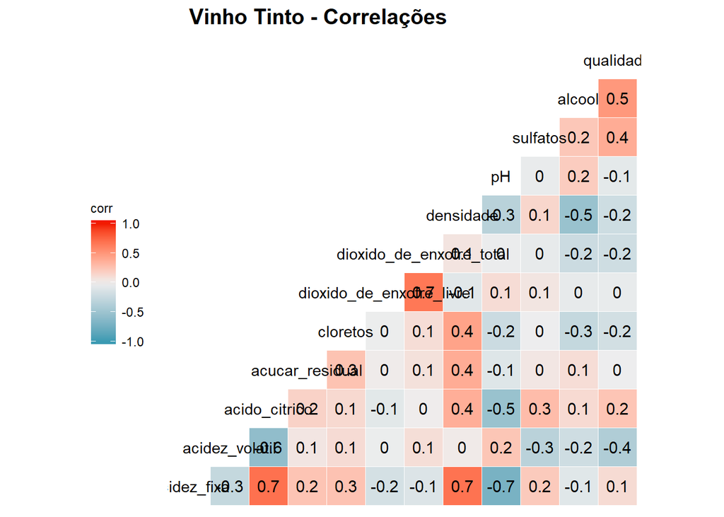

```r
ggcorr(red, name = "corr", label = TRUE) +
  theme(legend.position = "left") +
  labs(title = "Vinho Tinto - Correlações") +
  theme(plot.title = element_text(face = 'bold', color = 'black', hjust = 0.1, size = 15))
```

#### Vinhos Brancos

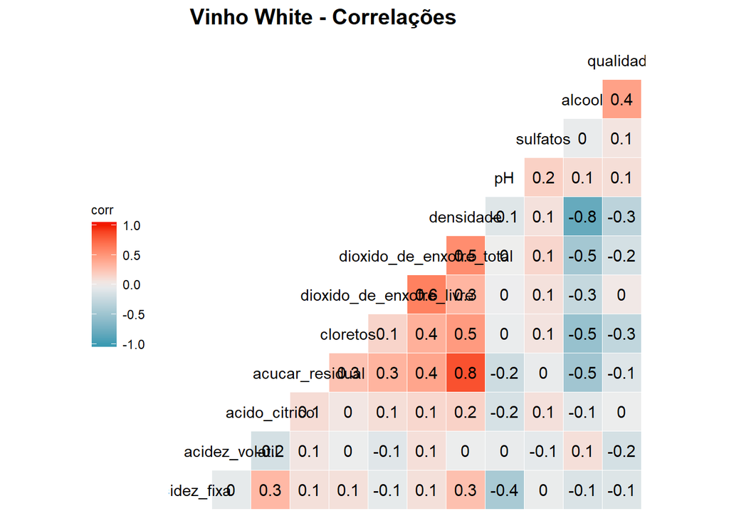

```r
ggcorr(white, name = "corr", label = TRUE) +
  theme(legend.position = "left") +
  labs(title = "Vinho White - Correlações") +
  theme(plot.title = element_text(face = 'bold', color = 'black', hjust = 0.1, size = 15))
```

### 5. Regressão Linear Multipla e Árvore de Regressão

```r
# carregar pacotes para esta sessão da EDA
library(car)
```

```r
library(rpart)
library(rpart.plot)
```

#### Vinhos Tintos

```r
modelo_reg_Red <- lm(red$qualidade ~ red$acidez_fixa + red$acidez_volatil + red$acido_citrico+ red$acucar_residual + red$cloretos + red$dioxido_de_enxofre_livre + red$dioxido_de_enxofre_total + red$pH +red$sulfatos + red$alcool)
summary(modelo_reg_Red)
```

```
##
## Call:
## lm(formula = red$qualidade ~ red$acidez_fixa + red$acidez_volatil +
##     red$acido_citrico + red$acucar_residual + red$cloretos +
##     red$dioxido_de_enxofre_livre + red$dioxido_de_enxofre_total +
##     red$pH + red$sulfatos + red$alcool)
##
## Residuals:
##      Min       1Q   Median       3Q      Max
## -2.71010 -0.36637 -0.03737  0.42345  1.91581
##
## Coefficients:
##                               Estimate Std. Error t value Pr(>|t|)
## (Intercept)                   4.855511   0.638559   7.604 5.19e-14 ***
## red$acidez_fixa              -0.001625   0.017743  -0.092   0.9271
## red$acidez_volatil           -0.949448   0.126007  -7.535 8.64e-14 ***
## red$acido_citrico            -0.159935   0.153614  -1.041   0.2980
## red$acucar_residual          -0.039225   0.030216  -1.298   0.1944
## red$cloretos                 -2.580346   1.115422  -2.313   0.0208 *
## red$dioxido_de_enxofre_livre  0.004006   0.002329   1.720   0.0857 .
## red$dioxido_de_enxofre_total -0.002953   0.000792  -3.729   0.0002 ***
## red$pH                       -0.671906   0.164851  -4.076 4.84e-05 ***
## red$sulfatos                  1.330216   0.137276   9.690  < 2e-16 ***
## red$alcool                    0.295150   0.018255  16.168  < 2e-16 ***
## ---
## Signif. codes:  0 '***' 0.001 '**' 0.01 '*' 0.05 '.' 0.1 ' ' 1
##
## Residual standard error: 0.626 on 1426 degrees of freedom
## Multiple R-squared:  0.3858, Adjusted R-squared:  0.3815
## F-statistic: 89.58 on 10 and 1426 DF,  p-value: < 2.2e-16
```

Ao rodar o modelo de regressão multipla para os vinhos tintos verificamos que as seguintes variáveis falharam ao predizer a variável qualidade por terem seu p-value acima de 5%, valor de referência para a inferência deste modelo:

- ´acidez fixa´
- ´acido citrico´
- ´açucar residual´
- ´dioxido de enxofre livre´

Vamos rodar o modelo novamente agora sem as variáveis citadas acima

```r
modelo_reg_Red_1 <- lm(red$qualidade ~ red$acidez_volatil + red$cloretos + red$dioxido_de_enxofre_total + red$pH +red$sulfatos + red$alcool)
summary(modelo_reg_Red_1)
```

```
##
## Call:
## lm(formula = red$qualidade ~ red$acidez_volatil + red$cloretos +
##     red$dioxido_de_enxofre_total + red$pH + red$sulfatos + red$alcool)
##
## Residuals:
##      Min       1Q   Median       3Q      Max
## -2.59790 -0.35132 -0.04552  0.42083  1.94366
##
## Coefficients:
##                                Estimate Std. Error t value Pr(>|t|)
## (Intercept)                   4.3699185  0.4323401  10.108  < 2e-16 ***
## red$acidez_volatil           -0.9045917  0.1049845  -8.616  < 2e-16 ***
## red$cloretos                 -3.2547379  1.0703652  -3.041   0.0024 **
## red$dioxido_de_enxofre_total -0.0021905  0.0005583  -3.923 9.15e-05 ***
## red$pH                       -0.5263375  0.1203706  -4.373 1.32e-05 ***
## red$sulfatos                  1.3116004  0.1334092   9.831  < 2e-16 ***
## red$alcool                    0.2882962  0.0174783  16.495  < 2e-16 ***
## ---
## Signif. codes:  0 '***' 0.001 '**' 0.01 '*' 0.05 '.' 0.1 ' ' 1
##
## Residual standard error: 0.6269 on 1430 degrees of freedom
## Multiple R-squared:  0.3824, Adjusted R-squared:  0.3798
## F-statistic: 147.6 on 6 and 1430 DF,  p-value: < 2.2e-16
```

Assim, obtemos um modelo com R² de 0.38 com as variáveis validadas. Embora a variável **dioxido de enxofre total** tenha sido validada pelo p-value, seu coeficiente é muito baixo (-0.0021), portanto vamos rodar o modelo novamente sem ela:

```r
modelo_reg_Red_2 <- lm(red$qualidade ~ red$acidez_volatil + red$cloretos + red$pH +red$sulfatos + red$alcool)
summary(modelo_reg_Red_2)
```

```
##
## Call:
## lm(formula = red$qualidade ~ red$acidez_volatil + red$cloretos +
##     red$pH + red$sulfatos + red$alcool)
##
## Residuals:
##      Min       1Q   Median       3Q      Max
## -2.58505 -0.35842 -0.06443  0.43573  2.01395
##
## Coefficients:
##                    Estimate Std. Error t value Pr(>|t|)
## (Intercept)         4.19037    0.43207   9.698  < 2e-16 ***
## red$acidez_volatil -0.92376    0.10540  -8.765  < 2e-16 ***
## red$cloretos       -3.43389    1.07476  -3.195  0.00143 **
## red$pH             -0.53381    0.12096  -4.413  1.1e-05 ***
## red$sulfatos        1.30236    0.13406   9.715  < 2e-16 ***
## red$alcool          0.30134    0.01725  17.474  < 2e-16 ***
## ---
## Signif. codes:  0 '***' 0.001 '**' 0.01 '*' 0.05 '.' 0.1 ' ' 1
##
## Residual standard error: 0.63 on 1431 degrees of freedom
## Multiple R-squared:  0.3757, Adjusted R-squared:  0.3736
## F-statistic: 172.3 on 5 and 1431 DF,  p-value: < 2.2e-16
```

Agora vamos fazer a análise de variancia (ANOVA) para liberar o modelo:

```r
anova(modelo_reg_Red_2)
```

|  | Df | Sum Sq | Mean Sq | F value | Pr(>F) |
| --- | --- | --- | --- | --- | --- |
| red$acidez_volatil | 1 | 136.78361753 | 136.78361753 | 344.60947841 | 4.274242e-69 |
| red$cloretos | 1 | 16.73450810 | 16.73450810 | 42.16053218 | 1.156661e-10 |
| red$pH | 1 | 0.01636565 | 0.01636565 | 0.04123124 | 8.391211e-01 |
| red$sulfatos | 1 | 67.13079373 | 67.13079373 | 169.12776713 | 1.250214e-36 |
| red$alcool | 1 | 121.19932789 | 121.19932789 | 305.34677999 | 3.984039e-62 |
| Residuals | 1431 | 567.99760003 | 0.39692355 | NA | NA |

Neste teste, temos a variável ´pH´ não foi aceita no teste F (p-value = 0.83 > 0.05). Sendo assim, vamos rodar o modelo linear multiplo sem a variável pH:

```r
modelo_reg_Red_3 <- lm(red$qualidade ~ red$acidez_volatil + red$cloretos + red$sulfatos + red$alcool)
summary(modelo_reg_Red_3)
```

```
##
## Call:
## lm(formula = red$qualidade ~ red$acidez_volatil + red$cloretos +
##     red$sulfatos + red$alcool)
##
## Residuals:
##      Min       1Q   Median       3Q      Max
## -2.69821 -0.36800 -0.06368  0.44810  2.06385
##
## Coefficients:
##                    Estimate Std. Error t value Pr(>|t|)
## (Intercept)         2.57999    0.23285  11.080   <2e-16 ***
## red$acidez_volatil -1.06021    0.10141 -10.455   <2e-16 ***
## red$cloretos       -2.47014    1.05910  -2.332   0.0198 *
## red$sulfatos        1.28969    0.13489   9.561   <2e-16 ***
## red$alcool          0.28624    0.01701  16.827   <2e-16 ***
## ---
## Signif. codes:  0 '***' 0.001 '**' 0.01 '*' 0.05 '.' 0.1 ' ' 1
##
## Residual standard error: 0.6341 on 1432 degrees of freedom
## Multiple R-squared:  0.3672, Adjusted R-squared:  0.3655
## F-statistic: 207.8 on 4 and 1432 DF,  p-value: < 2.2e-16
```

```r
anova(modelo_reg_Red_3)
```

|  | Df | Sum Sq | Mean Sq | F value | Pr(>F) |
| --- | --- | --- | --- | --- | --- |
| red$acidez_volatil | 1 | 136.78362 | 136.7836175 | 340.2199 | 2.498007e-68 |
| red$cloretos | 1 | 16.73451 | 16.7345081 | 41.6235 | 1.510069e-10 |
| red$sulfatos | 1 | 66.77847 | 66.7784692 | 166.0971 | 4.878322e-36 |
| red$alcool | 1 | 113.83762 | 113.8376184 | 283.1467 | 4.064560e-58 |
| Residuals | 1432 | 575.72800 | 0.4020447 | NA | NA |

Agora sim aceitamos o modelo de regressão múltipla Qualidade = -1.06 x Acidez_Volatil -2.47 x Cloretos + 1.28 x Sulfatos + 0.28 x Alcool + 2.58

Calculo do erro Quadratico Médio da média - Para comparar com o modelo de árvore de regressão que será feito em seguida:

```r
# estimar variáveis
vif(modelo_reg_Red_3)
```

```
## red$acidez_volatil       red$cloretos       red$sulfatos         red$alcool
##           1.146702           1.082711           1.157127           1.148479
```

```r
Val_pred <- predict(modelo_reg_Red_3,interval = "prediction", level = 0.95)
head(Val_pred)
```

```
##        fit      lwr      upr
## 1 5.558574 4.312155 6.804994
## 2 5.602737 4.357219 6.848254
## 3 5.216877 3.970629 6.463125
## 4 6.382080 5.134587 7.629573
## 5 4.996612 3.751287 6.241938
## 6 5.041133 3.795475 6.286791
```

```r
# intervalo de confianca - grafico para media
fit <- Val_pred[,1] # valores preditos
```

```r
# Erro Quadratico Médio da média para comparar modelos (não para avaliar a qualidade do modelo)
mse <- mean((red$qualidade - fit)^2)
sqrt(mse)
```

```
## [1] 0.6329659
```

```r
erro_usando_media <- mean((red$qualidade - mean(red$qualidade))^2)
sqrt(erro_usando_media)
```

```
## [1] 0.7957185
```

Agora vamos analisar a distribuição dos resíduos do modelo gerado através do qqplot e teste de Shapiro

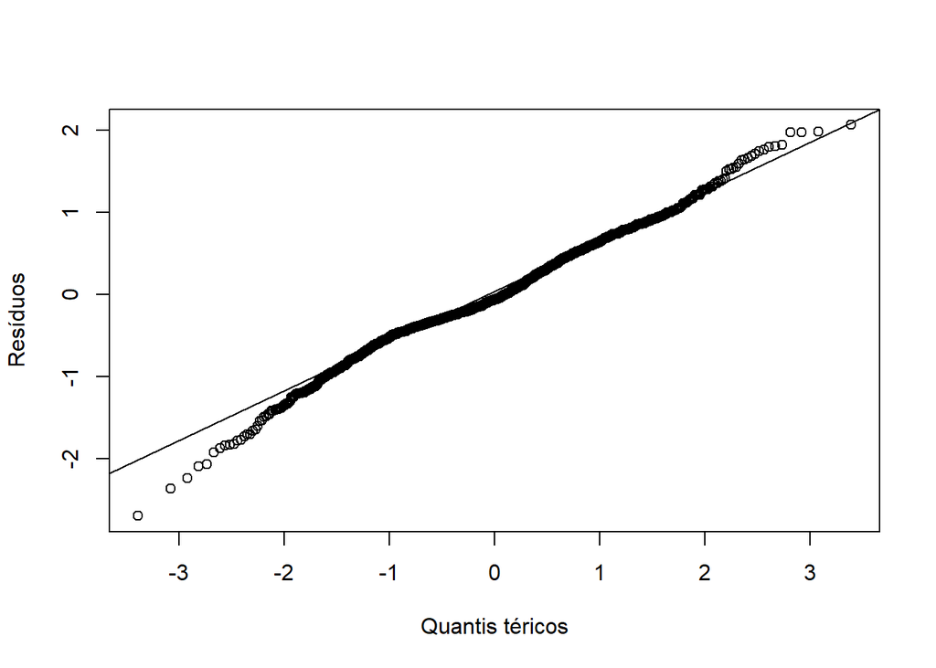

```r
qqnorm(residuals(modelo_reg_Red_3), ylab="Resíduos",xlab="Quantis téricos",main="")
qqline(residuals(modelo_reg_Red_3))
```

```r
#

shapiro.test(residuals(modelo_reg_Red_3))
```

```
##
##  Shapiro-Wilk normality test
##
## data:  residuals(modelo_reg_Red_3)
## W = 0.99037, p-value = 4.094e-08
```

No Teste de Normalidade de Shapiro Wilk, se o Pvalue do teste é pequeno, rejeita-se a hipótese de normalidade dos resíduos e, por consequência, conclui-se que os erros não são normalmente distribuídos.Ao contrário dos demais testes de hipóteses neste caso de Pvalue < alpha, rejeita-se H0!!! É o que acontece para os resíduos do modelo de regressão linear dos vinhos tintos.

Árvore de Regressão:

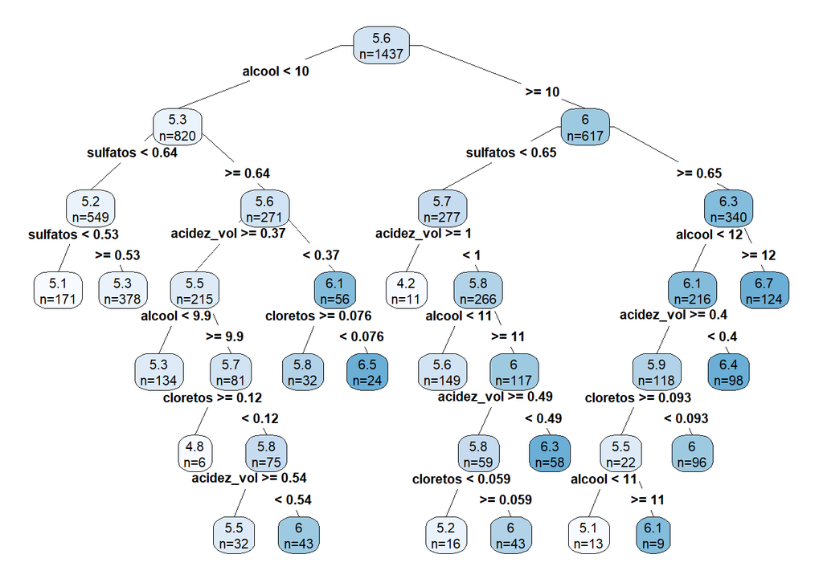

```r
modelo_Valor_tree <- rpart (qualidade ~ acidez_volatil + cloretos + sulfatos + alcool, data=red,
                     cp = 0.005,minsplit = 15,maxdepth=10)

rpart.plot(modelo_Valor_tree, type=4, extra=1, under=FALSE, clip.right.labs=TRUE,
           fallen.leaves=FALSE,   digits=2, varlen=-10, faclen=20,
           cex=0.4, tweak=1.7,
           compress=TRUE,
           snip=FALSE)
```

```r
Val_pred_tree <- predict(modelo_Valor_tree,interval = "prediction", level = 0.95)
mse_tree <- mean((red$qualidade - Val_pred_tree)^2)
sqrt(mse_tree)
```

```
## [1] 0.5967068
```

```r
erro_usando_media <- mean((red$qualidade - mean(red$qualidade))^2)
sqrt(erro_usando_media)
```

```
## [1] 0.7957185
```

#### Vinhos Brancos

```r
modelo_reg_White <- lm(white$qualidade ~ white$acidez_fixa + white$acidez_volatil + white$acido_citrico+ white$acucar_residual + white$cloretos + white$dioxido_de_enxofre_livre + white$dioxido_de_enxofre_total + white$pH + white$sulfatos + white$alcool)
summary(modelo_reg_White)
```

```
##
## Call:
## lm(formula = white$qualidade ~ white$acidez_fixa + white$acidez_volatil +
##     white$acido_citrico + white$acucar_residual + white$cloretos +
##     white$dioxido_de_enxofre_livre + white$dioxido_de_enxofre_total +
##     white$pH + white$sulfatos + white$alcool)
##
## Residuals:
##     Min      1Q  Median      3Q     Max
## -3.3109 -0.4995 -0.0323  0.4493  3.1222
##
## Coefficients:
##                                  Estimate Std. Error t value Pr(>|t|)
## (Intercept)                     1.8642204  0.3608362   5.166 2.49e-07 ***
## white$acidez_fixa              -0.0306093  0.0154263  -1.984  0.04729 *
## white$acidez_volatil           -1.9597190  0.1277916 -15.335  < 2e-16 ***
## white$acido_citrico            -0.1179345  0.1064847  -1.108  0.26812
## white$acucar_residual           0.0264841  0.0026578   9.965  < 2e-16 ***
## white$cloretos                 -5.1843804  1.2020334  -4.313 1.64e-05 ***
## white$dioxido_de_enxofre_livre  0.0064487  0.0008955   7.201 6.91e-13 ***
## white$dioxido_de_enxofre_total -0.0006024  0.0003879  -1.553  0.12047
## white$pH                        0.2232824  0.0838125   2.664  0.00775 **
## white$sulfatos                  0.4780185  0.1007988   4.742 2.18e-06 ***
## white$alcool                    0.3591177  0.0121005  29.678  < 2e-16 ***
## ---
## Signif. codes:  0 '***' 0.001 '**' 0.01 '*' 0.05 '.' 0.1 ' ' 1
##
## Residual standard error: 0.7481 on 4681 degrees of freedom
## Multiple R-squared:  0.2749, Adjusted R-squared:  0.2733
## F-statistic: 177.5 on 10 and 4681 DF,  p-value: < 2.2e-16
```

Ao rodar o modelo de regressão multipla para os vinhos brancos verificamos que as seguintes variáveis falharam ao predizer a variável qualidade por terem seu p-value acima de 5%, valor de referência para a inferência deste modelo:

- ´acido citrico´
- ´dioxido de enxofre total´

Vamos rodar o modelo novamente agora sem as variáveis citadas acima

```r
modelo_reg_White_1 <- lm(white$qualidade ~ white$acidez_fixa + white$acidez_volatil + white$acucar_residual + white$cloretos + white$dioxido_de_enxofre_livre + white$pH + white$sulfatos + white$alcool)
summary(modelo_reg_White_1)
```

```
##
## Call:
## lm(formula = white$qualidade ~ white$acidez_fixa + white$acidez_volatil +
##     white$acucar_residual + white$cloretos + white$dioxido_de_enxofre_livre +
##     white$pH + white$sulfatos + white$alcool)
##
## Residuals:
##     Min      1Q  Median      3Q     Max
## -3.3076 -0.5073 -0.0302  0.4469  3.1290
##
## Coefficients:
##                                  Estimate Std. Error t value Pr(>|t|)
## (Intercept)                     1.8645527  0.3606952   5.169 2.45e-07 ***
## white$acidez_fixa              -0.0386127  0.0147497  -2.618  0.00888 **
## white$acidez_volatil           -1.9825739  0.1228141 -16.143  < 2e-16 ***
## white$acucar_residual           0.0257204  0.0026292   9.783  < 2e-16 ***
## white$cloretos                 -5.4795762  1.1873045  -4.615 4.03e-06 ***
## white$dioxido_de_enxofre_livre  0.0055878  0.0007327   7.626 2.91e-14 ***
## white$pH                        0.2102287  0.0831316   2.529  0.01148 *
## white$sulfatos                  0.4497724  0.0998078   4.506 6.75e-06 ***
## white$alcool                    0.3630957  0.0117649  30.863  < 2e-16 ***
## ---
## Signif. codes:  0 '***' 0.001 '**' 0.01 '*' 0.05 '.' 0.1 ' ' 1
##
## Residual standard error: 0.7483 on 4683 degrees of freedom
## Multiple R-squared:  0.2743, Adjusted R-squared:  0.273
## F-statistic: 221.2 on 8 and 4683 DF,  p-value: < 2.2e-16
```

Assim, obtemos um modelo com R² de 0.27 com as variáveis validadas. Embora as variáveis **acidez fixa, açucar residual e dioxido de enxofre livre** tenham sido validadas pelo p-value, possuem coeficientes muito baixos (0.02 e 0.00558), portanto vamos rodar o modelo novamente sem elas:

```r
modelo_reg_White_2 <- lm(white$qualidade ~ white$acidez_volatil +white$cloretos + white$pH + white$sulfatos + white$alcool)
summary(modelo_reg_White_2)
```

```
##
## Call:
## lm(formula = white$qualidade ~ white$acidez_volatil + white$cloretos +
##     white$pH + white$sulfatos + white$alcool)
##
## Residuals:
##     Min      1Q  Median      3Q     Max
## -3.4183 -0.4852 -0.0573  0.4867  3.1025
##
## Coefficients:
##                      Estimate Std. Error t value Pr(>|t|)
## (Intercept)           2.72662    0.26960  10.114  < 2e-16 ***
## white$acidez_volatil -1.90295    0.12425 -15.316  < 2e-16 ***
## white$cloretos       -5.47117    1.21375  -4.508 6.71e-06 ***
## white$pH              0.17758    0.07589   2.340   0.0193 *
## white$sulfatos        0.47080    0.10173   4.628 3.80e-06 ***
## white$alcool          0.29725    0.01089  27.293  < 2e-16 ***
## ---
## Signif. codes:  0 '***' 0.001 '**' 0.01 '*' 0.05 '.' 0.1 ' ' 1
##
## Residual standard error: 0.7657 on 4686 degrees of freedom
## Multiple R-squared:  0.2397, Adjusted R-squared:  0.2389
## F-statistic: 295.5 on 5 and 4686 DF,  p-value: < 2.2e-16
```

Agora não temos mais variáveis com p-value abaixo de 5% ou coeficientes muito baixos, porém nosso R² diminuiu para 0.23. Vamos executar a validação final do modelo para os vinhos brancos usando ANOVA:

```r
anova(modelo_reg_White_2)
```

|  | Df | Sum Sq | Mean Sq | F value | Pr(>F) |
| --- | --- | --- | --- | --- | --- |
| white$acidez_volatil | 1 | 96.44918 | 96.4491805 | 164.52047 | 4.856988e-37 |
| white$cloretos | 1 | 297.79699 | 297.7969888 | 507.97426 | 6.986036e-107 |
| white$pH | 1 | 24.67712 | 24.6771193 | 42.09358 | 9.600482e-11 |
| white$sulfatos | 1 | 10.53635 | 10.5363460 | 17.97262 | 2.284190e-05 |
| white$alcool | 1 | 436.71163 | 436.7116329 | 744.93120 | 2.380004e-152 |
| Residuals | 4686 | 2747.14054 | 0.5862442 | NA | NA |

Todas as variáveis passaram no teste F. Modelo Qualidade = -1.90 x Acidez Voltail -5.47 x Cloretos + 0.17 x pH + 0.475 x Sulfato + 0.29 Alcool + 2.72 Calculo do erro Quadratico Médio da média - Para comparar com o modelo de árvore de regressão que será feito em seguida:

```r
# estimar variáveis
vif(modelo_reg_White_2)
```

```
## white$acidez_volatil       white$cloretos             white$pH
##             1.014100             1.408023             1.046351
##       white$sulfatos         white$alcool
##             1.036803             1.433571
```

```r
Val_pred <- predict(modelo_reg_White_2,interval = "prediction", level = 0.95)
head(Val_pred)
```

```
##        fit      lwr      upr
## 1 5.962057 4.460372 7.463742
## 2 6.381324 4.879453 7.883196
## 3 5.749520 4.247296 7.251744
## 4 5.350607 3.848988 6.852226
## 5 6.270064 4.768261 7.771867
## 6 5.593485 4.091498 7.095472
```

```r
# intervalo de confianca - grafico para media
fit <- Val_pred[,1] # valores preditos
```

```r
# Erro Quadratico Médio da média para comparar modelos (não para avaliar a qualidade do modelo)
mse <- mean((white$qualidade - fit)^2)
sqrt(mse)
```

```
## [1] 0.7651762
```

```r
erro_usando_media <- mean((red$qualidade - mean(red$qualidade))^2)
sqrt(erro_usando_media)
```

```
## [1] 0.7957185
```

Agora vamos analisar a distribuição dos resíduos do modelo gerado através do qqplot e teste de Shapiro

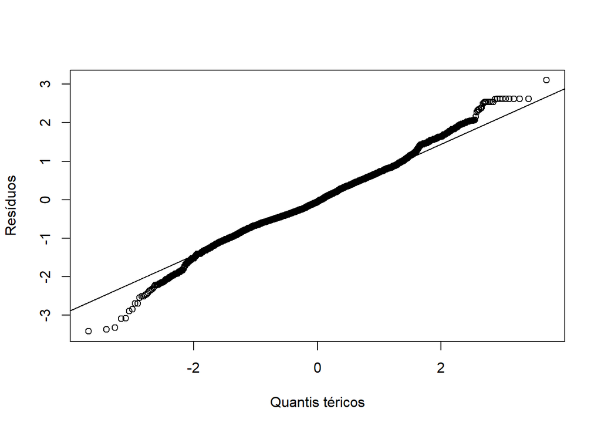

```r
qqnorm(residuals(modelo_reg_White_2), ylab="Resíduos",xlab="Quantis téricos",main="")
qqline(residuals(modelo_reg_White_2))
```

```r
# teste de shapiro
shapiro.test(residuals(modelo_reg_White_2))
```

```
##
##  Shapiro-Wilk normality test
##
## data:  residuals(modelo_reg_White_2)
## W = 0.99036, p-value < 2.2e-16
```

No Teste de Normalidade de Shapiro Wilk, se o Pvalue do teste é pequeno, rejeita-se a hipótese de normalidade dos resíduos e, por consequência, conclui-se que os erros não são normalmente distribuídos.Ao contrário dos demais testes de hipóteses neste caso de Pvalue < alpha, rejeita-se H0!!! É o que acontece para os resíduos do modelo de regressão linear dos vinhos brancos.

Árvore de Regressão:

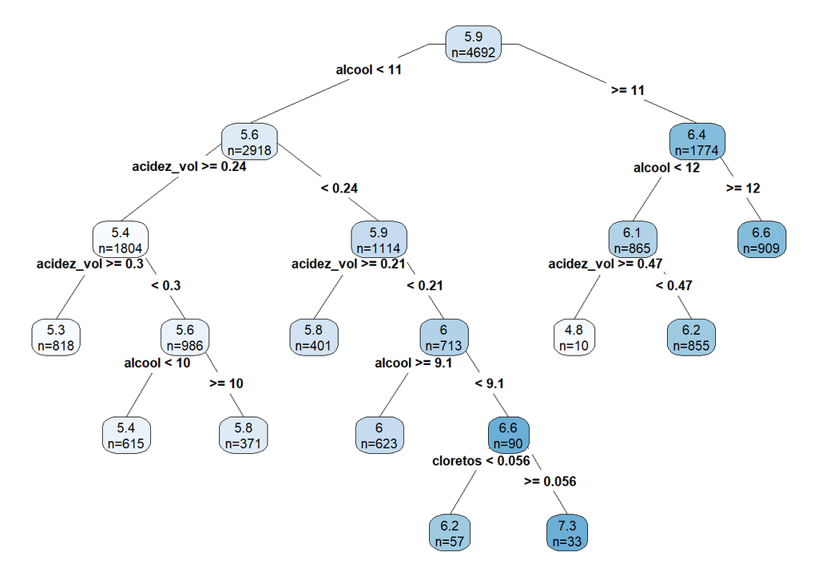

```r
modelo_Valor_tree <- rpart (qualidade ~ acidez_volatil + cloretos + pH +sulfatos + alcool, data=white,
                     cp = 0.005,minsplit = 15,maxdepth=10)

rpart.plot(modelo_Valor_tree, type=4, extra=1, under=FALSE, clip.right.labs=TRUE,
           fallen.leaves=FALSE,   digits=2, varlen=-10, faclen=20,
           cex=0.4, tweak=1.7,
           compress=TRUE,
           snip=FALSE)
```

```r
Val_pred_tree <- predict(modelo_Valor_tree,interval = "prediction", level = 0.95)
mse_tree <- mean((white$qualidade - Val_pred_tree)^2)
sqrt(mse_tree)
```

```
## [1] 0.7460753
```

```r
erro_usando_media <- mean((white$qualidade - mean(white$qualidade))^2)
sqrt(erro_usando_media)
```

```
## [1] 0.8775537
```

### 6. Regressão Logística e Árvore de Decisão

```r
# carregando pacotes necessários para a regressão logística
library(caret)
library(mlbench)
library(rattle)
library(e1071)
```

#### Vinhos Tintos

```r
# criando nova variável binária para classificação da qualidade dos vinhos, onde 0 - Ruim, para os vinhos com qualidade inferior a 6 e 1- Bom para vinhos com qualidade igual ou superior a 6
red$qualy[red$qualidade < 6] = 0
red$qualy[red$qualidade >= 6] = 1
str(red)
```

```
## 'data.frame':    1437 obs. of  15 variables:
##  $ acidez_fixa             : num  10.6 6.8 6.6 7.2 7.2 7.1 6.4 9 7.3 6.8 ...
##  $ acidez_volatil          : num  0.31 0.5 0.61 0.66 0.63 0.735 0.31 0.58 0.735 0.57 ...
##  $ acido_citrico           : num  0.49 0.11 0 0.33 0 0.16 0.09 0.25 0 0 ...
##  $ acucar_residual         : num  2.2 1.5 1.6 2.5 1.9 1.9 1.4 2 2.2 2.5 ...
##  $ cloretos                : num  0.063 0.075 0.069 0.068 0.097 0.1 0.066 0.104 0.08 0.072 ...
##  $ dioxido_de_enxofre_livre: num  18 16 4 34 14 15 15 8 18 32 ...
##  $ dioxido_de_enxofre_total: num  40 49 8 102 38 77 28 21 28 64 ...
##  $ densidade               : num  0.998 0.995 0.994 0.994 0.997 ...
##  $ pH                      : num  3.14 3.36 3.33 3.27 3.37 3.27 3.42 3.27 3.41 3.43 ...
##  $ sulfatos                : num  0.51 0.79 0.37 0.78 0.58 0.64 0.7 0.72 0.6 0.56 ...
##  $ alcool                  : num  9.8 9.5 10.4 12.8 9 9.3 10 9.6 9.4 11.2 ...
##  $ qualidade               : num  6 5 4 6 6 5 7 5 5 6 ...
##  $ vinho                   : chr  "RED" "RED" "RED" "RED" ...
##  $ vinhos_fator            : Factor w/ 2 levels "RED","WHITE": 1 1 1 1 1 1 1 1 1 1 ...
##  $ qualy                   : num  1 0 0 1 1 0 1 0 0 1 ...
```

```r
red$qualy <- factor(red$qualy)
```

```r
#separação dos dados de treino e teste
#Divisao do banco de dados completo em treinamento e teste
#definir % de casos de treino


# amostra de casos de treino aleatória
set.seed(109)

# Divide o dataset em 80% para treino e 20% para teste
trainIndex <- createDataPartition(red$qualy, p=0.80, list=FALSE)
trainData <- red[trainIndex,]
testData <- red[-trainIndex,]

print('Proporção de Vinhos Ruins e Bons:')
```

```
## [1] "Proporção de Vinhos Ruins e Bons:"
```

```r
print('Dados de Treino:')
```

```
## [1] "Dados de Treino:"
```

```r
prop.table(table(trainData$qualy))
```

```
##
##    0    1
## 0.46 0.54
```

```r
print('Dados de Teste: ')
```

```
## [1] "Dados de Teste: "
```

```r
prop.table(table(testData$qualy))
```

```
##
##         0         1
## 0.4599303 0.5400697
```

```r
# informações dos Parâmetros do Modelo
## Usa rpart para decision tree
attach(trainData)
```

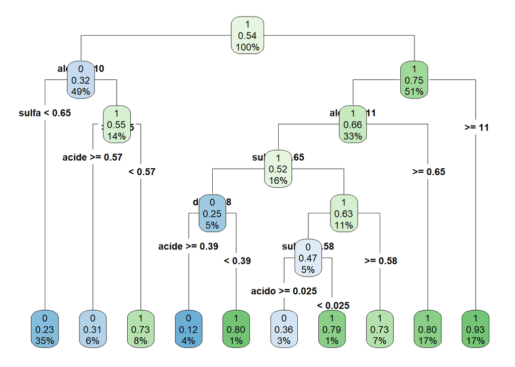

```r
modelo_tree_1 <- rpart(qualy ~ acidez_fixa + acidez_volatil + acido_citrico + acucar_residual + cloretos + dioxido_de_enxofre_livre + dioxido_de_enxofre_total +pH + sulfatos + alcool, data=trainData, control = rpart.control(cp = 0.01))
# Faz o Gráfico
rpart.plot(modelo_tree_1, type=4, under=FALSE, clip.right.labs=TRUE,
           fallen.leaves=TRUE, digits=2, varlen=-3, faclen=12,
           cex=NULL, tweak=2,
           compress=TRUE,
           snip=FALSE)
```

```r
summary(modelo_tree_1)
```

```
## Call:
## rpart(formula = qualy ~ acidez_fixa + acidez_volatil + acido_citrico +
##     acucar_residual + cloretos + dioxido_de_enxofre_livre + dioxido_de_enxofre_total +
##     pH + sulfatos + alcool, data = trainData, control = rpart.control(cp = 0.01))
##   n= 1150
##
##           CP nsplit rel error    xerror       xstd
## 1 0.38563327      0 1.0000000 1.0000000 0.03194987
## 2 0.04064272      1 0.6143667 0.6578450 0.02944911
## 3 0.01701323      3 0.5330813 0.6200378 0.02894465
## 4 0.01134216      6 0.4820416 0.5671078 0.02814916
## 5 0.01039698      7 0.4706994 0.5425331 0.02774225
## 6 0.01000000      9 0.4499055 0.5463138 0.02780647
##
## Variable importance
##                   alcool                 sulfatos           acidez_volatil
##                       33                       19                       13
##            acido_citrico dioxido_de_enxofre_total                 cloretos
##                       10                        9                        8
##              acidez_fixa dioxido_de_enxofre_livre                       pH
##                        3                        3                        2
##          acucar_residual
##                        1
##
## Node number 1: 1150 observations,    complexity param=0.3856333
##   predicted class=1  expected loss=0.46  P(node) =1
##     class counts:   529   621
##    probabilities: 0.460 0.540
##   left son=2 (566 obs) right son=3 (584 obs)
##   Primary splits:
##       alcool                   < 10.15  to the left,  improve=108.09690, (0 missing)
##       sulfatos                 < 0.645  to the left,  improve= 74.11301, (0 missing)
##       acidez_volatil           < 0.5475 to the right, improve= 58.49140, (0 missing)
##       dioxido_de_enxofre_total < 94.5   to the right, improve= 37.58063, (0 missing)
##       acido_citrico            < 0.295  to the left,  improve= 32.41904, (0 missing)
##   Surrogate splits:
##       sulfatos                 < 0.595  to the left,  agree=0.634, adj=0.256, (0 split)
##       cloretos                 < 0.0725 to the right, agree=0.623, adj=0.233, (0 split)
##       dioxido_de_enxofre_total < 63.5   to the right, agree=0.618, adj=0.224, (0 split)
##       acidez_volatil           < 0.535  to the right, agree=0.613, adj=0.214, (0 split)
```

[output cut: 175 more lines]

```
##
## Node number 51: 78 observations
##   predicted class=1  expected loss=0.2692308  P(node) =0.06782609
##     class counts:    21    57
##    probabilities: 0.269 0.731
##
## Node number 100: 39 observations
##   predicted class=0  expected loss=0.3589744  P(node) =0.03391304
##     class counts:    25    14
##    probabilities: 0.641 0.359
##
## Node number 101: 14 observations
##   predicted class=1  expected loss=0.2142857  P(node) =0.01217391
##     class counts:     3    11
##    probabilities: 0.214 0.786
```

```r
# aplica o modelo no arquivo teste

## Predict com tipo 'classe' retorna se o vinho é bom ou não
red.previsao <- predict(modelo_tree_1, testData ,type = 'class')
```

```r
red.matriz.confusao_tree <- table(testData$qualy, red.previsao)
red.matriz.confusao_tree
```

```
##    red.previsao
##       0   1
##   0  98  34
##   1  46 109
```

```r
diagonal <- diag(red.matriz.confusao_tree)
Acc_tree_teste <- sum(diagonal)/sum(red.matriz.confusao_tree)
print(Acc_tree_teste*100, digits=5)
```

```
## [1] 72.125
```

[figure not shown]

```r
#plotar regra do modelo preditivo

fancyRpartPlot(modelo_tree_1, cex=0.60)
```

Regressão Logística

```r
Mod_Log_red <- glm(qualidade ~ acidez_fixa + acidez_volatil + acido_citrico + acucar_residual + cloretos + dioxido_de_enxofre_livre + dioxido_de_enxofre_total +pH + sulfatos + alcool, data = trainData)

summary(Mod_Log_red)
```

```
##
## Call:
## glm(formula = qualidade ~ acidez_fixa + acidez_volatil + acido_citrico +
##     acucar_residual + cloretos + dioxido_de_enxofre_livre + dioxido_de_enxofre_total +
##     pH + sulfatos + alcool, data = trainData)
##
## Deviance Residuals:
##      Min        1Q    Median        3Q       Max
## -2.76046  -0.34983  -0.03239   0.40564   1.92285
##
## Coefficients:
##                            Estimate Std. Error t value Pr(>|t|)
## (Intercept)               4.4781028  0.7137847   6.274 5.00e-10 ***
## acidez_fixa              -0.0119926  0.0197968  -0.606 0.544778
## acidez_volatil           -1.0176045  0.1386150  -7.341 4.02e-13 ***
## acido_citrico            -0.1130290  0.1683905  -0.671 0.502209
## acucar_residual           0.0097611  0.0340848   0.286 0.774642
## cloretos                 -1.8350222  1.2217933  -1.502 0.133398
## dioxido_de_enxofre_livre  0.0058374  0.0026035   2.242 0.025145 *
## dioxido_de_enxofre_total -0.0030983  0.0008647  -3.583 0.000354 ***
## pH                       -0.5850206  0.1844335  -3.172 0.001554 **
## sulfatos                  1.3671221  0.1523289   8.975  < 2e-16 ***
## alcool                    0.2934982  0.0202450  14.497  < 2e-16 ***
## ---
## Signif. codes:  0 '***' 0.001 '**' 0.01 '*' 0.05 '.' 0.1 ' ' 1
##
## (Dispersion parameter for gaussian family taken to be 0.3834067)
##
##     Null deviance: 725.79  on 1149  degrees of freedom
## Residual deviance: 436.70  on 1139  degrees of freedom
## AIC: 2174
##
## Number of Fisher Scoring iterations: 2
```

Pelo p-values, descartamos as variáveis acidez fixa, acido critrico, açucar residual e cloretos. Por ter um coeficiente muito baixo no modelo também descartamos as variáveis dioxido de enxofre livre e dioxido de enxofre total.

```r
Mod_Log_red_1 <- glm(qualidade ~ acidez_volatil + pH + sulfatos + alcool, data = trainData)

summary(Mod_Log_red_1)
```

```
##
## Call:
## glm(formula = qualidade ~ acidez_volatil + pH + sulfatos + alcool,
##     data = trainData)
##
## Deviance Residuals:
##      Min        1Q    Median        3Q       Max
## -2.82873  -0.35249  -0.05226   0.43321   1.95447
##
## Coefficients:
##                Estimate Std. Error t value Pr(>|t|)
## (Intercept)     3.16552    0.43743   7.237  8.4e-13 ***
## acidez_volatil -1.02886    0.11478  -8.964  < 2e-16 ***
## pH             -0.33513    0.13131  -2.552   0.0108 *
## sulfatos        1.32851    0.14824   8.962  < 2e-16 ***
## alcool          0.31375    0.01864  16.834  < 2e-16 ***
## ---
## Signif. codes:  0 '***' 0.001 '**' 0.01 '*' 0.05 '.' 0.1 ' ' 1
##
## (Dispersion parameter for gaussian family taken to be 0.3881313)
##
##     Null deviance: 725.79  on 1149  degrees of freedom
## Residual deviance: 444.41  on 1145  degrees of freedom
## AIC: 2182.2
##
## Number of Fisher Scoring iterations: 2
```

```r
red.previsao <- predict.glm(Mod_Log_red_1, newdata = testData ,type = 'response')
red.previsao_cut <- as.factor(ifelse(red.previsao > 6, 1, 0))
confusionMatrix(red.previsao_cut, testData$qualy)
```

```
## Confusion Matrix and Statistics
##
##           Reference
## Prediction   0   1
##          0 122  89
##          1  10  66
##
##                Accuracy : 0.6551
##                  95% CI : (0.5969, 0.7099)
##     No Information Rate : 0.5401
##     P-Value [Acc > NIR] : 5.058e-05
##
##                   Kappa : 0.3352
##
##  Mcnemar's Test P-Value : 4.531e-15
##
##             Sensitivity : 0.9242
##             Specificity : 0.4258
##          Pos Pred Value : 0.5782
##          Neg Pred Value : 0.8684
##              Prevalence : 0.4599
##          Detection Rate : 0.4251
##    Detection Prevalence : 0.7352
##       Balanced Accuracy : 0.6750
##
##        'Positive' Class : 0
##
```

#### Vinhos Brancos

```r
# criando nova variável binária para classificação da qualidade dos vinhos, onde 0 - Ruim, para os vinhos com qualidade inferior a 6 e 1- Bom para vinhos com qualidade igual ou superior a 6
white$qualy[white$qualidade < 6] = 0
white$qualy[white$qualidade >= 6] = 1
str(white)
```

```
## 'data.frame':    4692 obs. of  15 variables:
##  $ acidez_fixa             : num  6.6 6.7 5.4 6.7 5.1 6.2 6.6 7.3 6.7 6.2 ...
##  $ acidez_volatil          : num  0.24 0.34 0.18 0.3 0.26 0.22 0.25 0.27 0.26 0.12 ...
##  $ acido_citrico           : num  0.35 0.43 0.24 0.44 0.33 0.2 0.36 0.37 0.29 0.26 ...
##  $ acucar_residual         : num  7.7 1.6 4.8 18.8 1.1 ...
##  $ cloretos                : num  0.031 0.041 0.041 0.057 0.027 0.035 0.045 0.042 0.038 0.044 ...
##  $ dioxido_de_enxofre_livre: num  36 29 30 65 46 58 54 36 40 56 ...
##  $ dioxido_de_enxofre_total: num  135 114 113 224 113 184 180 130 179 158 ...
##  $ densidade               : num  0.994 0.99 0.994 1 0.989 ...
##  $ pH                      : num  3.19 3.23 3.42 3.11 3.35 3.11 3.08 3.48 3.23 3.52 ...
##  $ sulfatos                : num  0.37 0.44 0.4 0.53 0.43 0.53 0.42 0.75 0.56 0.37 ...
##  $ alcool                  : num  10.5 12.6 9.4 9.1 11.4 9 9.2 9.9 10.4 10.5 ...
##  $ qualidade               : num  5 6 6 5 7 6 5 6 6 6 ...
##  $ vinho                   : chr  "WHITE" "WHITE" "WHITE" "WHITE" ...
##  $ vinhos_fator            : Factor w/ 2 levels "RED","WHITE": 2 2 2 2 2 2 2 2 2 2 ...
##  $ qualy                   : num  0 1 1 0 1 1 0 1 1 1 ...
```

```r
white$qualy <- factor(white$qualy)
```

```r
#separação dos dados de treino e teste
#Divisao do banco de dados completo em treinamento e teste
#definir % de casos de treino


# amostra de casos de treino aleatória
set.seed(109)

# Divide o dataset em 80% para treino e 20% para teste
trainIndex <- createDataPartition(white$qualy, p=0.80, list=FALSE)
trainData <- white[trainIndex,]
testData <- white[-trainIndex,]

print('Proporção de Vinhos Ruins e Bons:')
```

```
## [1] "Proporção de Vinhos Ruins e Bons:"
```

```r
print('Dados de Treino:')
```

```
## [1] "Dados de Treino:"
```

```r
prop.table(table(trainData$qualy))
```

```
##
##         0         1
## 0.3252531 0.6747469
```

```r
print('Dados de Teste: ')
```

```
## [1] "Dados de Teste: "
```

```r
prop.table(table(testData$qualy))
```

```
##
##         0         1
## 0.3251599 0.6748401
```

```r
# informações dos Parâmetros do Modelo
## Usa rpart para decision tree
attach(trainData)
```

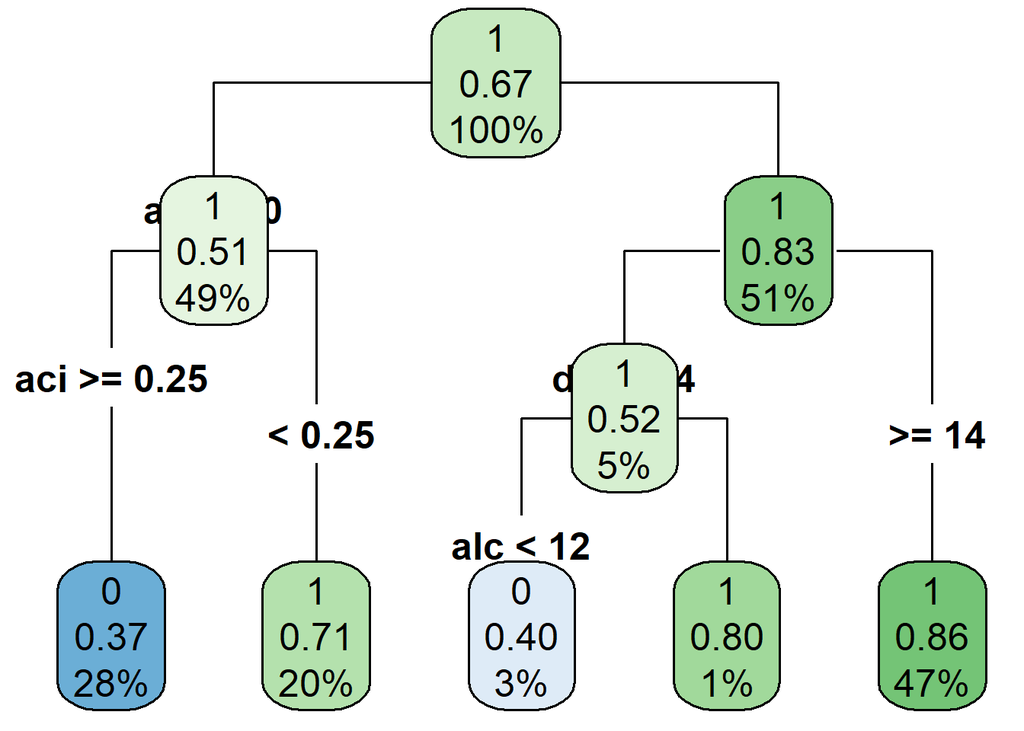

```r
modelo_tree_1 <- rpart(qualy ~ acidez_fixa + acidez_volatil + acido_citrico + acucar_residual + cloretos + dioxido_de_enxofre_livre + dioxido_de_enxofre_total +pH + sulfatos + alcool, data=trainData, control = rpart.control(cp = 0.01))
# Faz o Gráfico
rpart.plot(modelo_tree_1, type=4, under=FALSE, clip.right.labs=TRUE,
           fallen.leaves=TRUE, digits=2, varlen=-3, faclen=12,
           cex=NULL, tweak=2,
           compress=TRUE,
           snip=FALSE)
```

```r
summary(modelo_tree_1)
```

```
## Call:
## rpart(formula = qualy ~ acidez_fixa + acidez_volatil + acido_citrico +
##     acucar_residual + cloretos + dioxido_de_enxofre_livre + dioxido_de_enxofre_total +
##     pH + sulfatos + alcool, data = trainData, control = rpart.control(cp = 0.01))
##   n= 3754
##
##           CP nsplit rel error    xerror       xstd
## 1 0.11547912      0 1.0000000 1.0000000 0.02350783
## 2 0.01064701      2 0.7690418 0.7886978 0.02191443
## 3 0.01000000      4 0.7477477 0.7706798 0.02174788
##
## Variable importance
##                   alcool           acidez_volatil dioxido_de_enxofre_total
##                       31                       16                       13
##                 cloretos dioxido_de_enxofre_livre          acucar_residual
##                       13                       12                       11
##            acido_citrico                       pH                 sulfatos
##                        3                        1                        1
##
## Node number 1: 3754 observations,    complexity param=0.1154791
##   predicted class=1  expected loss=0.3252531  P(node) =1
##     class counts:  1221  2533
##    probabilities: 0.325 0.675
##   left son=2 (1825 obs) right son=3 (1929 obs)
##   Primary splits:
##       alcool                   < 10.35    to the left,  improve=191.19250, (0 missing)
##       cloretos                 < 0.0395   to the right, improve= 90.99120, (0 missing)
##       acidez_volatil           < 0.2325   to the right, improve= 71.03640, (0 missing)
##       dioxido_de_enxofre_total < 158.5    to the right, improve= 55.74574, (0 missing)
##       acido_citrico            < 0.235    to the left,  improve= 55.22767, (0 missing)
##   Surrogate splits:
##       cloretos                 < 0.0405   to the right, agree=0.720, adj=0.424, (0 split)
##       acucar_residual          < 7.025    to the right, agree=0.701, adj=0.386, (0 split)
##       dioxido_de_enxofre_total < 140.5    to the right, agree=0.694, adj=0.372, (0 split)
##       dioxido_de_enxofre_livre < 43.75    to the right, agree=0.623, adj=0.225, (0 split)
##       acido_citrico            < 0.265    to the left,  agree=0.564, adj=0.102, (0 split)
##
## Node number 2: 1825 observations,    complexity param=0.1154791
##   predicted class=1  expected loss=0.4893151  P(node) =0.4861481
##     class counts:   893   932
```

[output cut: 57 more lines]

```
##
## Node number 7: 1751 observations
##   predicted class=1  expected loss=0.1382067  P(node) =0.4664358
##     class counts:   242  1509
##    probabilities: 0.138 0.862
##
## Node number 12: 124 observations
##   predicted class=0  expected loss=0.3951613  P(node) =0.03303143
##     class counts:    75    49
##    probabilities: 0.605 0.395
##
## Node number 13: 54 observations
##   predicted class=1  expected loss=0.2037037  P(node) =0.01438466
##     class counts:    11    43
##    probabilities: 0.204 0.796
```

```r
# aplica o modelo no arquivo teste

## Predict com tipo 'classe' retorna se o vinho é bom ou não
white.previsao <- predict(modelo_tree_1, testData ,type = 'class')
```

```r
white.matriz.confusao_tree <- table(testData$qualy, white.previsao)
white.matriz.confusao_tree
```

```
##    white.previsao
##       0   1
##   0 179 126
##   1 112 521
```

```r
diagonal <- diag(white.matriz.confusao_tree)
Acc_tree_teste <- sum(diagonal)/sum(white.matriz.confusao_tree)
print(Acc_tree_teste*100, digits=5)
```

```
## [1] 74.627
```

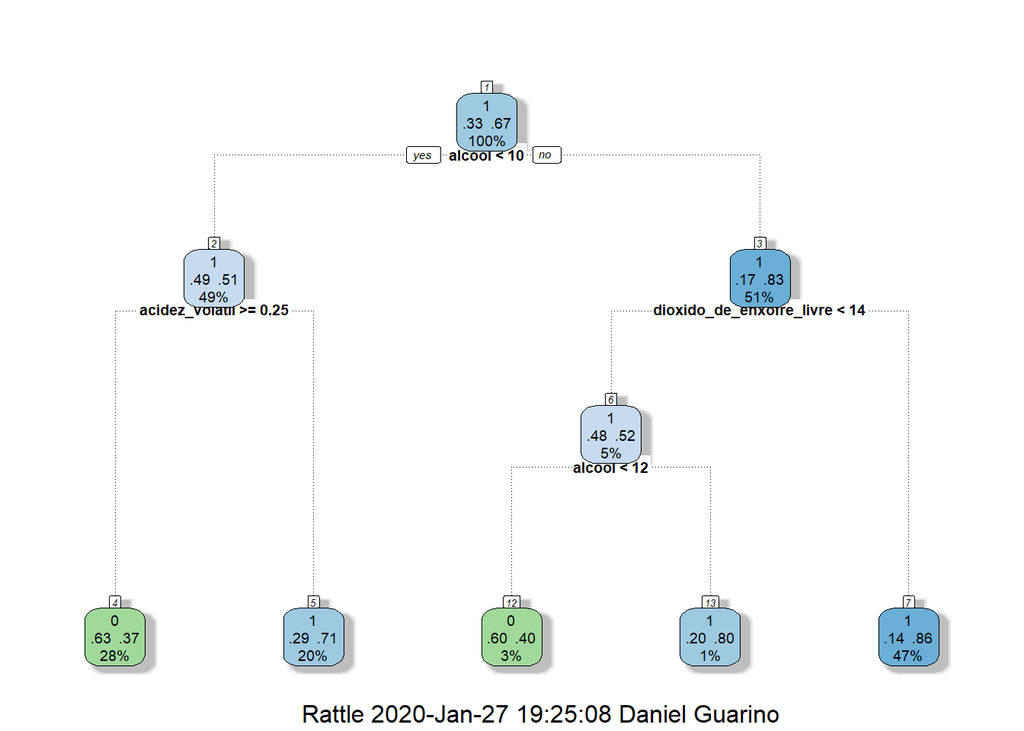

```r
#plotar regra do modelo preditivo

fancyRpartPlot(modelo_tree_1, cex=0.60)
```

Regressão Logística

```r
Mod_Log_white <- glm(qualidade ~ acidez_fixa + acidez_volatil + acido_citrico + acucar_residual + cloretos + dioxido_de_enxofre_livre + dioxido_de_enxofre_total +pH + sulfatos + alcool, data = trainData)

summary(Mod_Log_white)
```

```
##
## Call:
## glm(formula = qualidade ~ acidez_fixa + acidez_volatil + acido_citrico +
##     acucar_residual + cloretos + dioxido_de_enxofre_livre + dioxido_de_enxofre_total +
##     pH + sulfatos + alcool, data = trainData)
##
## Deviance Residuals:
##     Min       1Q   Median       3Q      Max
## -3.3075  -0.5003  -0.0301   0.4541   3.1330
##
## Coefficients:
##                            Estimate Std. Error t value Pr(>|t|)
## (Intercept)               2.0247185  0.4046759   5.003 5.89e-07 ***
## acidez_fixa              -0.0376133  0.0174478  -2.156   0.0312 *
## acidez_volatil           -2.0157097  0.1459508 -13.811  < 2e-16 ***
## acido_citrico            -0.1290491  0.1216090  -1.061   0.2887
## acucar_residual           0.0258630  0.0029974   8.628  < 2e-16 ***
## cloretos                 -5.8131253  1.3515550  -4.301 1.74e-05 ***
## dioxido_de_enxofre_livre  0.0074216  0.0010129   7.327 2.87e-13 ***
## dioxido_de_enxofre_total -0.0008456  0.0004403  -1.921   0.0549 .
## pH                        0.2335669  0.0944314   2.473   0.0134 *
## sulfatos                  0.4739662  0.1137444   4.167 3.16e-05 ***
## alcool                    0.3507542  0.0136496  25.697  < 2e-16 ***
## ---
## Signif. codes:  0 '***' 0.001 '**' 0.01 '*' 0.05 '.' 0.1 ' ' 1
##
## (Dispersion parameter for gaussian family taken to be 0.5663177)
##
##     Null deviance: 2919.5  on 3753  degrees of freedom
## Residual deviance: 2119.7  on 3743  degrees of freedom
## AIC: 8531.8
##
## Number of Fisher Scoring iterations: 2
```

```r
Mod_Log_white_1 <- glm(qualidade ~ acidez_fixa + acidez_volatil + acido_citrico + acucar_residual + cloretos + dioxido_de_enxofre_livre + dioxido_de_enxofre_total +pH + sulfatos + alcool, data = trainData)

summary(Mod_Log_white_1)
```

```
##
## Call:
## glm(formula = qualidade ~ acidez_fixa + acidez_volatil + acido_citrico +
##     acucar_residual + cloretos + dioxido_de_enxofre_livre + dioxido_de_enxofre_total +
##     pH + sulfatos + alcool, data = trainData)
##
## Deviance Residuals:
##     Min       1Q   Median       3Q      Max
## -3.3075  -0.5003  -0.0301   0.4541   3.1330
##
## Coefficients:
##                            Estimate Std. Error t value Pr(>|t|)
## (Intercept)               2.0247185  0.4046759   5.003 5.89e-07 ***
## acidez_fixa              -0.0376133  0.0174478  -2.156   0.0312 *
## acidez_volatil           -2.0157097  0.1459508 -13.811  < 2e-16 ***
## acido_citrico            -0.1290491  0.1216090  -1.061   0.2887
## acucar_residual           0.0258630  0.0029974   8.628  < 2e-16 ***
## cloretos                 -5.8131253  1.3515550  -4.301 1.74e-05 ***
## dioxido_de_enxofre_livre  0.0074216  0.0010129   7.327 2.87e-13 ***
## dioxido_de_enxofre_total -0.0008456  0.0004403  -1.921   0.0549 .
## pH                        0.2335669  0.0944314   2.473   0.0134 *
## sulfatos                  0.4739662  0.1137444   4.167 3.16e-05 ***
## alcool                    0.3507542  0.0136496  25.697  < 2e-16 ***
## ---
## Signif. codes:  0 '***' 0.001 '**' 0.01 '*' 0.05 '.' 0.1 ' ' 1
##
## (Dispersion parameter for gaussian family taken to be 0.5663177)
##
##     Null deviance: 2919.5  on 3753  degrees of freedom
## Residual deviance: 2119.7  on 3743  degrees of freedom
## AIC: 8531.8
##
## Number of Fisher Scoring iterations: 2
```

```r
white.previsao <- predict.glm(Mod_Log_white_1, newdata = testData ,type = 'response')
white.previsao_cut <- as.factor(ifelse(white.previsao > 6, 1, 0))
confusionMatrix(white.previsao_cut, testData$qualy)
```

```
## Confusion Matrix and Statistics
##
##           Reference
## Prediction   0   1
##          0 259 274
##          1  46 359
##
##                Accuracy : 0.6588
##                  95% CI : (0.6275, 0.6892)
##     No Information Rate : 0.6748
##     P-Value [Acc > NIR] : 0.8599
##
##                   Kappa : 0.3488
##
##  Mcnemar's Test P-Value : <2e-16
##
##             Sensitivity : 0.8492
##             Specificity : 0.5671
##          Pos Pred Value : 0.4859
##          Neg Pred Value : 0.8864
##              Prevalence : 0.3252
##          Detection Rate : 0.2761
##    Detection Prevalence : 0.5682
##       Balanced Accuracy : 0.7082
##
##        'Positive' Class : 0
##
```

### Métodos Não Supervisionados

Com o intuito de avaliar a importação de **vinhos brancos** será feita uma análise utilizando métodos não supervisionados. #### Vinhos Brancos

##### PCA

```r
str(white[1:11])
```

```
## 'data.frame':    4692 obs. of  11 variables:
##  $ acidez_fixa             : num  6.6 6.7 5.4 6.7 5.1 6.2 6.6 7.3 6.7 6.2 ...
##  $ acidez_volatil          : num  0.24 0.34 0.18 0.3 0.26 0.22 0.25 0.27 0.26 0.12 ...
##  $ acido_citrico           : num  0.35 0.43 0.24 0.44 0.33 0.2 0.36 0.37 0.29 0.26 ...
##  $ acucar_residual         : num  7.7 1.6 4.8 18.8 1.1 ...
##  $ cloretos                : num  0.031 0.041 0.041 0.057 0.027 0.035 0.045 0.042 0.038 0.044 ...
##  $ dioxido_de_enxofre_livre: num  36 29 30 65 46 58 54 36 40 56 ...
##  $ dioxido_de_enxofre_total: num  135 114 113 224 113 184 180 130 179 158 ...
##  $ densidade               : num  0.994 0.99 0.994 1 0.989 ...
##  $ pH                      : num  3.19 3.23 3.42 3.11 3.35 3.11 3.08 3.48 3.23 3.52 ...
##  $ sulfatos                : num  0.37 0.44 0.4 0.53 0.43 0.53 0.42 0.75 0.56 0.37 ...
##  $ alcool                  : num  10.5 12.6 9.4 9.1 11.4 9 9.2 9.9 10.4 10.5 ...
```

```r
#escala log dos dados somente com as variáveis numéricas (sem incluir a variável target "qualidade")
white_new <- white[1:11]
white_scale <- scale(white_new)
head(white_scale)
```

```
##      acidez_fixa acidez_volatil acido_citrico acucar_residual   cloretos
## [1,]  -0.3018578     -0.3644552   0.174416217       0.2573930 -1.0868732
## [2,]  -0.1813048      0.7392133   0.896552456      -0.9585473 -0.1718825
## [3,]  -1.7484935     -1.0266563  -0.818521110      -0.3206770 -0.1718825
## [4,]  -0.1813048      0.2977459   0.986819486       2.4600388  1.2921026
## [5,]  -2.1101524     -0.1437215  -0.006117842      -1.0582145 -1.4528695
## [6,]  -0.7840697     -0.5851889  -1.179589229       2.8686744 -0.7208770
##      dioxido_de_enxofre_livre dioxido_de_enxofre_total   densidade           pH
## [1,]               0.05623204              -0.06856721 -0.06614628 -0.005389283
## [2,]              -0.37700396              -0.57203721 -1.31275682  0.260085949
## [3,]              -0.31511310              -0.59601198  0.15524630  1.521093298
## [4,]               1.85106689               2.06518663  1.89573261 -0.536339746
## [5,]               0.67514061              -0.59601198 -1.54436752  1.056511643
## [6,]               1.41783089               1.10619614  2.12053123 -0.536339746
##        sulfatos      alcool
## [1,] -1.0623556 -0.03007511
## [2,] -0.4367369  1.67860292
## [3,] -0.7942333 -0.92509693
## [4,]  0.3676301 -1.16919379
## [5,] -0.5261110  0.70221548
## [6,]  0.3676301 -1.25055941
```

```r
summary(white_scale)
```

```
##   acidez_fixa       acidez_volatil    acido_citrico      acucar_residual
##  Min.   :-3.67734   Min.   :-2.1303   Min.   :-2.98493   Min.   :-1.1579
##  1st Qu.:-0.66352   1st Qu.:-0.6956   1st Qu.:-0.54772   1st Qu.:-0.9386
##  Median :-0.06075   Median :-0.1437   Median :-0.09638   Median :-0.2409
##  Mean   : 0.00000   Mean   : 0.0000   Mean   : 0.00000   Mean   : 0.0000
##  3rd Qu.: 0.54201   3rd Qu.: 0.5185   3rd Qu.: 0.44522   3rd Qu.: 0.6959
##  Max.   : 4.15860   Max.   : 4.1606   Max.   : 3.69483   Max.   : 5.0215
##     cloretos        dioxido_de_enxofre_livre dioxido_de_enxofre_total
##  Min.   :-3.09985   Min.   :-2.04806         Min.   :-3.06541
##  1st Qu.:-0.72088   1st Qu.:-0.74835         1st Qu.:-0.71589
##  Median :-0.08038   Median :-0.06755         Median :-0.09254
##  Mean   : 0.00000   Mean   : 0.00000         Mean   : 0.00000
##  3rd Qu.: 0.65161   3rd Qu.: 0.67514         3rd Qu.: 0.69863
##  Max.   : 4.49457   Max.   : 4.75994         Max.   : 4.94216
##    densidade             pH              sulfatos           alcool
##  Min.   :-2.3448   Min.   :-3.12472   Min.   :-2.4030   Min.   :-2.0642
##  1st Qu.:-0.7814   1st Qu.:-0.66908   1st Qu.:-0.7049   1st Qu.:-0.8437
##  Median :-0.1002   Median :-0.07176   Median :-0.1686   Median :-0.1114
##  Mean   : 0.0000   Mean   : 0.00000   Mean   : 0.0000   Mean   : 0.0000
##  3rd Qu.: 0.7172   3rd Qu.: 0.59193   3rd Qu.: 0.5464   3rd Qu.: 0.7022
##  Max.   : 5.5538   Max.   : 4.17585   Max.   : 4.3001   Max.   : 2.9805
```

```r
# PCA
white_pca <- prcomp(white[1:11], scale = TRUE)
summary(white_pca)
```

```
## Importance of components:
##                           PC1    PC2    PC3     PC4     PC5     PC6     PC7
## Standard deviation     1.8605 1.2626 1.1135 1.01983 0.97541 0.87007 0.84648
## Proportion of Variance 0.3147 0.1449 0.1127 0.09455 0.08649 0.06882 0.06514
## Cumulative Proportion  0.3147 0.4596 0.5723 0.66687 0.75337 0.82219 0.88733
##                           PC8     PC9    PC10   PC11
## Standard deviation     0.7416 0.62087 0.53820 0.1195
## Proportion of Variance 0.0500 0.03504 0.02633 0.0013
## Cumulative Proportion  0.9373 0.97237 0.99870 1.0000
```

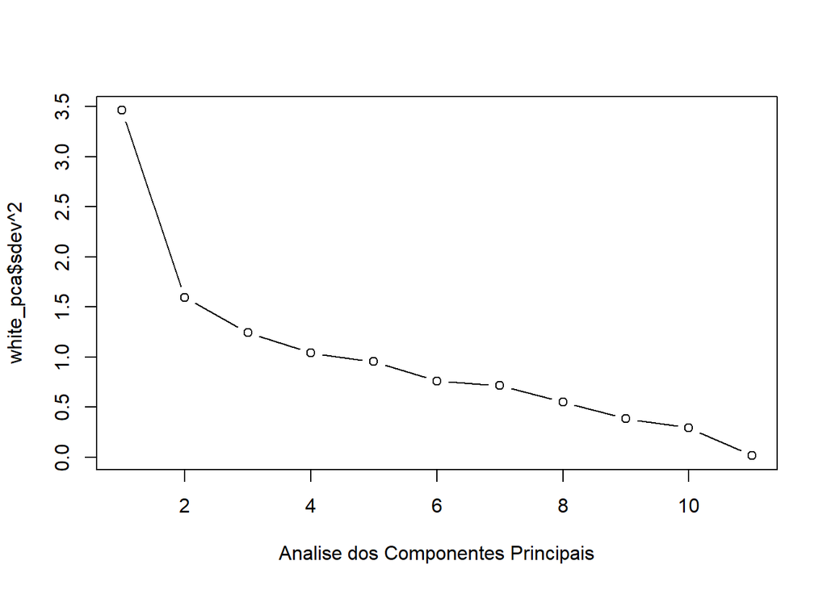

```r
plot(1:11, white_pca$sdev^2, type = 'b', xlab = 'Analise dos Componentes Principais')
```

Utilizar 3 clusters para visualização dos Clusters

```r
# k-means
set.seed(231)
clusters <- kmeans(white[9:10], 3)
clusters$size
```

```
## [1]  942 2422 1328
```

```r
# entidades dentro de cada cluster
centres <- clusters$centers
centres
```

```
##         pH  sulfatos
## 1 3.196476 0.6414331
## 2 3.093910 0.4376837
## 3 3.363524 0.4739910
```

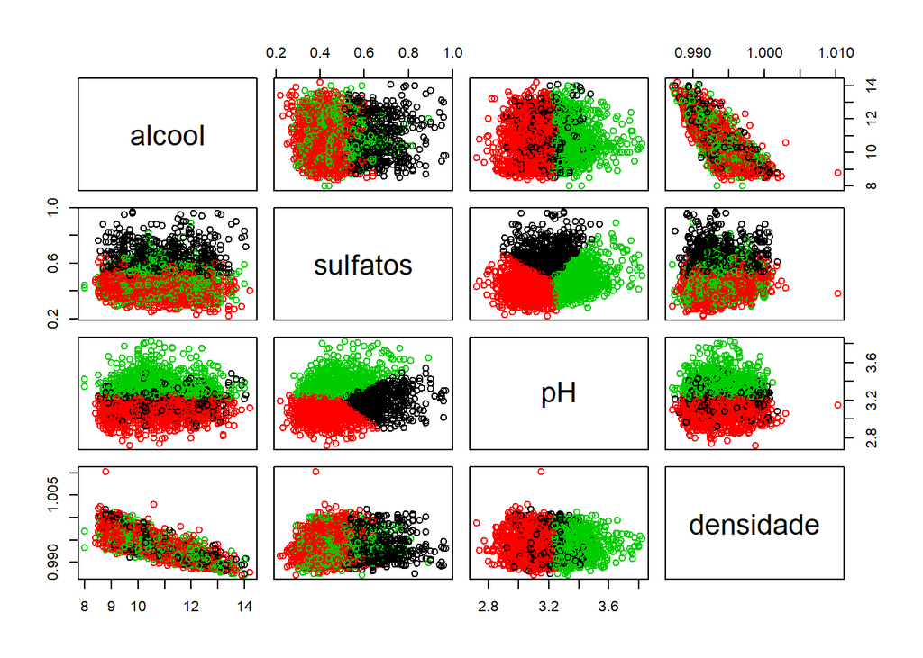

```r
plot(white[11:8], col =  clusters$cluster, pch = 21)
points(clusters$centers[11:1], col = "BLUE", pch = 7, cex = 3.5)
```

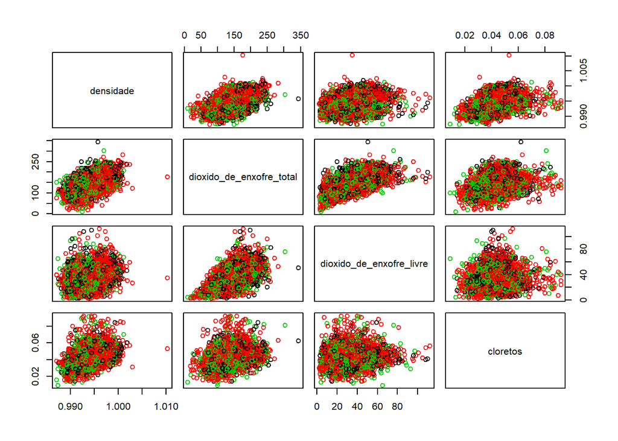

```r
plot(white[8:5], col =  clusters$cluster, pch = 21)
points(clusters$centers[8:5], col = "BLUE", pch = 7, cex = 3.5)
```

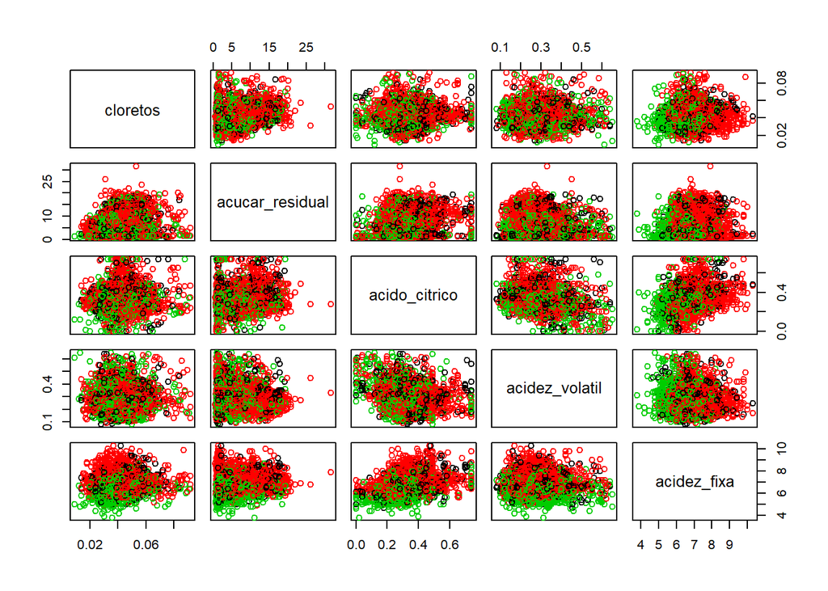

```r
plot(white[5:1], col =  clusters$cluster, pch = 21)
points(clusters$centers[5:1], col = "BLUE", pch = 7, cex = 3.5)
```

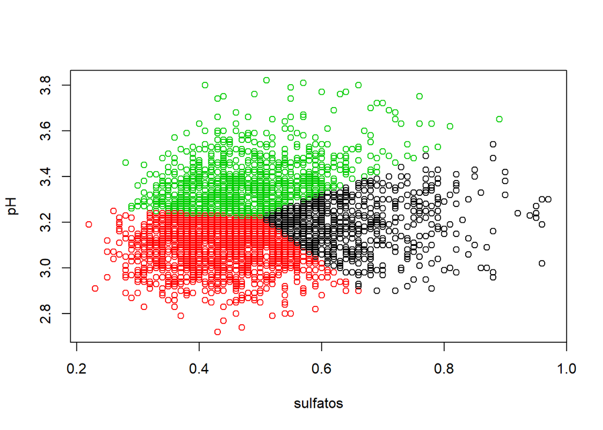

```r
plot(white[10:9], col =  clusters$cluster, pch = 21)
points(clusters$centers[10:9], col = "BLUE", pch = 7, cex = 3.5)
```

### Conclusão Final

Comparando os modelos de regressão linear multipla e árvore de regressão obtemos:

- `Vinhos Tintos`: Árvore de regressão se saiu melhor com o menor erro quadrático médio (0.59) contra o modelo de regressao multipla (0.63)
- `Vinhos Brancos`: Novamente a árvore de regressão se saiu melhor contra o modelo de regressão linear, mas por uma margem bastante apertada (0.74 contra 0.76)

Modelo de regressão logistica: